# APLS shinytest Scratchpad 1: Fix overlap-fixing

Dan Villarreal

28 Sep 2022

```r
knitr::opts_chunk$set(echo=T, include=T, comment=NA)
library(tidyverse)
library(magrittr)
library(shiny)
library(shinytest)
library(xml2)
```

# 1 Intro

From my TODO:

- Order tiers by importance (main speaker(s) > interviewer > bystander(s)), and align overlaps from least important to most important
  - Add new test files: Ensure interviewer is snapped to main speaker(s)
  - So I can eventually add Redaction as the highest priority (since we need to delete exactly the right audio)

First, the necessary functions:

```r
nonSpkrTiers <- c("Comment","Noise","Redaction")
overlapThresh <- 500

##Function that takes a tier name, eaf file, and file-wide time slot DF as
##  input and outputs actual times for annotations
getTimesTier <- function(tierName, eaf, timeSlots) {
  tierTimes <-
    ##Get all ALIGNABLE_ANNOTATION tags
    str_glue("//TIER[@TIER_ID='{tierName}']//ALIGNABLE_ANNOTATION") %>%
    xml_find_all(eaf, .) %>%
    ##Get attributes as a dataframe
    xml_attrs() %>%
    bind_rows()

  ##Add actual times, only if tier is nonempty
  if (nrow(tierTimes) > 0) {
    tierTimes <- tierTimes %>%
      ##Add actual times
      left_join(timeSlots %>%
                  rename(TIME_SLOT_REF1 = TIME_SLOT_ID,
                         Start = TIME_VALUE),
                by="TIME_SLOT_REF1") %>%
      left_join(timeSlots %>%
                  rename(TIME_SLOT_REF2 = TIME_SLOT_ID,
                         End = TIME_VALUE),
                by="TIME_SLOT_REF2")
  } else {
    ##If tier is empty, return NULL (will be immediately discard()ed)
    NULL
  }
}

##Wrapper function around getTimesTier() that takes a single EAF file and name
##  (meant to be used with eaflist() reactive and imap()) plus multi-file tier
##  df (meant to be used with tierInfo() reactive) as input, and outputs nested
##  list of dataframes of annotation times (files at level one, tier DFs at
##  level two for speaker tiers only)
##N.B. This function outputs a list of DFs rather than a single DF because the
##  list structure makes it easier to detect overlaps in findOverlaps() (by
##  comparing the timings on a given speaker tier to all other speaker tiers)
getTimes <- function(eaf, eafName, df) {
  ##Timeslots (maps time slot ID to actual time, in milliseconds)
  timeSlots <-
    ##Get TIME_SLOT nodes
    eaf %>%
    xml_find_all("//TIME_SLOT") %>%
    ##Get attributes as a dataframe
    xml_attrs() %>%
    bind_rows() %>%
    ##Make actual time numeric
    mutate(across(TIME_VALUE, as.numeric))

  ##Get speaker tier names
  spkrTierNames <-
    ##df intended to be tierInfo() reactive
    df %>%
    filter(File==eafName, SpkrTier) %>%
    pull(TIER_ID)

  ##Get times for speaker tiers (list of dataframes)
  spkrTimes <-
    spkrTierNames %>%
    set_names(., .) %>%
    map(getTimesTier, eaf, timeSlots) %>%
    ##Only nonempty tiers
    discard(is.null)
}

##Function that takes a single tier name and a nested list of annotation time
##  DFs (meant to be used with output of getTimes()), and outputs a single
##  dataframe: the relevant annotation time DF plus three boolean overlaps
##  columns (left, right, both), where TRUE means there is at least one
##  annotation on another tier whose (e.g.) left boundary is within the
##  annotation
findOverlapsTier <- function(tierName, timesEAF) {
  ##Get annotation timing DF for selected speaker
  spkr <- timesEAF %>% pluck(tierName)
  ##Get annotation timing DF that combines all other speakers
  otherSpkrs <-
    timesEAF %>%
    extract(names(.) != tierName) %>%
    bind_rows()

  ##For each boundary in selected tier, return the first annotation that the
  ##  boundary overlaps with, if any
  ##Currently isn't guaranteed to work with 3+ speaker tiers (because
  ##  which(x)[1] only selects the first result, not necessarily the result
  ##  closest to the boundary)
  bounds <-
    spkr %>%
    ##One row per boundary (new columns Side, TIME_SLOT_REF, Time)
    rename(Time1 = Start, Time2 = End) %>%
    pivot_longer(-ANNOTATION_ID,
                 names_to=c(".value", "Side"), names_pattern="(.+)([12])") %>%
    ##Check row-by-row (otherwise comparison in which() doesn't work)
    rowwise() %>%
    ##Add overlap annotation ID
    ##N.B. This works because if which(x) is integer(0), which(x)[1] is NA
    mutate(ANNOTATION_ID_overlapped = otherSpkrs$ANNOTATION_ID %>%
             extract(which(Time > otherSpkrs$Start & Time < otherSpkrs$End)[1])) %>%
    ungroup()

  ##Restrict to boundaries with overlaps, and add information about overlapped
  ##  annotations
  overlapBounds <-
    bounds %>%
    ##Only the boundaries that overlap another annotation
    filter(!is.na(ANNOTATION_ID_overlapped)) %>%
    ##Add info about overlapped annotation
    left_join(otherSpkrs %>%
                rename_with(~ paste0(.x, "_overlapped")),
              by="ANNOTATION_ID_overlapped") %>%
    ##Determine whether the nearest boundary is close enough (rowwise for min())
    rowwise() %>%
    mutate(StartDiff = abs(Start_overlapped - Time),
           EndDiff = abs(End_overlapped - Time),
           CloseEnough = min(StartDiff, EndDiff) < overlapThresh) %>%
    ungroup()

  ##Add new timeslot ID: if not close enough, "Too far"; if close enough, closer
  ##  boundary (tie goes to start boundary); anything else is unexpected so it
  ##  triggers an error below
  overlapBounds <- overlapBounds %>%
    mutate(NewTS = case_when(
      !CloseEnough ~ "Too far",
      StartDiff <= EndDiff ~ TIME_SLOT_REF1_overlapped,
      StartDiff > EndDiff ~ TIME_SLOT_REF2_overlapped,
      TRUE ~ NA_character_),
      ##Add node path for fixing overlap
      NodePath = str_glue("//ALIGNABLE_ANNOTATION[@ANNOTATION_ID='{ANNOTATION_ID}']"))

  ##Return dataframe
  overlapBounds
}

##Check for problems with overlapBounds, fix any overlaps by modifying eaflist(),
##  and return overlapBounds with info about fixed boundaries
fixOverlapsTier <- function(overlapBounds, eaflist, eafName) {
  ##Check for boundaries where NewTS is NA
  if (any(is.na(overlapBounds$NewTS))) {
    stop("On tier ", tierName,
         ", at least one boundary returned an error: ",
         overlapBounds %>%
           filter(is.na(NewTS)) %>%
           pull(ANNOTATION_ID) %>%
           paste(collapse=" "))
  }

  ##Get fixed boundaries only
  overlapBoundsFixed <-
    overlapBounds %>%
    filter(NewTS != "Too far")

  ##If no boundaries fixed, return dataframe with all unresolved
  if (nrow(overlapBoundsFixed)==0) {
    overlapBounds <- overlapBounds %>%
      mutate(Resolved = FALSE)
    return(overlapBounds)
  }

  ##Otherwise, check for issues in overlaps
  ##Check for annotation IDs that don't select a unique node within EAF file
  nodeCount <-
    overlapBoundsFixed$NodePath %>%
    map_int(~ xml_find_all(eaflist[[eafName]], .x) %>%
              xml_length())
  if (any(nodeCount > 1)) {
    stop("On tier ", tierName,
         ", at least one annotation ID doesn't select a unique node: ",
         overlapBoundsFixed %>%
           filter(NodeCount > 1) %>%
           pull(ANNOTATION_ID) %>%
           paste(collapse=" "))
  }

  ##Check for annotations that have accidentally become 0-width
  ##This could happen if the annotation is less than overlapThresh wide and
  ##  is fully contained within another annotation on another tier. Could
  ##  mitigate this by re-running with a smaller overlapThresh
  zeroWidth <-
    overlapBoundsFixed %>%
    select(ANNOTATION_ID:Time, NewTS) %>%
    pivot_wider(names_from=Side, names_glue="{.value}{Side}",
                values_from=TIME_SLOT_REF:NewTS) %>%
    filter(NewTS1==NewTS2)
  if (nrow(zeroWidth) > 0) {
    stop("On tier ", tierName,
         ", at least one annotation was fixed to zero width:\n",
         "ANN_ID  Start   End\n",
         paste0(str_pad(zeroWidth$ANNOTATION_ID, 8, 'right'),
                str_pad(round(zeroWidth$Time1 / 1000, 1), 8, 'right'),
                str_pad(round(zeroWidth$Time2 / 1000, 1), 8, 'right'),
                "\n"))
  }

  ##Fix overlaps in eaflist()
  overlapBoundsFixed %>%
    rowwise() %>%
    group_walk(
      ~ eaflist %>%
        pluck(eafName) %>%
        xml_find_first(.x$NodePath) %>%
        ##Note xml_set_attr() modifies without assignment (!!!)
        xml_set_attr(paste0("TIME_SLOT_REF", .x$Side), .x$NewTS))

  ##Add fixed info to dataframe
  overlapBounds <- overlapBounds %>%
    mutate(Resolved = NewTS!="Too far")

  ##Return dataframe
  overlapBounds
}

##Wrapper function around getTimesTier() that takes a *list* of DFs of
##  annotation times (one files' worth) and a single EAF name (meant to be used
##  with output of getTimes() and imap()), and outputs a *single* DF with
##  annotation times plus overlaps columns
findOverlaps <- function(timesEAF, eafName) {
  ##Loop over tiers within this file to get overlaps
  timesEAF %>%
    names() %>%
    set_names(., .) %>%
    map(findOverlapsTier, timesEAF=timesEAF)
}

##Wrapper function around fixOverlapsTier() that takes a *list* of DFs of
##  annotation times (one file's worth) and a single EAF name (meant to be used
##  with output of getTimes() and imap()), and rotates through tiers, fixing
##  overlaps, until it reaches a stable state
fixOverlaps <- function(timesEAF, eaflist, eafName) {
  # ##Initialize empty overlap log
  # overlapLog <- data.frame(Tier = character(),
  #                          NumBounds = character(),
  #                          NumOverlaps = character(),
  #                          NumFixed = character())

  ##Get initial overlaps
  overlapsInit <-
    ##Get tier names
    timesEAF %>%
    names() %>%
    set_names(., .) %>%
    ##Loop over tier names to find overlaps
    map(findOverlapsTier, timesEAF)

  ##Initialize looping variables
  overlapsPre <- NULL
  overlapsPost <- overlapsInit
  iters <- 0
  maxIter <- 10

  ##Continue until there are no remaining overlaps, either because all
  ##  overlaps have been fixed, or because things have stablized
  while (any(map_int(overlapsPost, nrow) > 0) && !identical(overlapsPre, overlapsPost)) {
    ##Increment iteration counter & stop if above maxIter
    iters <- iters + 1
    if (iters > maxIter) {
      stop("Overlap fixing reached max iterations (", maxIter, ")")
    }

    ##Old post is new pre
    overlapsPre <- overlapsPost

    ##Go through another fixing round
    overlapsPost <-
      overlapsPre %>%
      map(fixOverlapsTier, eaflist, eafName) %>%
      map(filter, !Resolved)

    message("iters: ", iters)
    message("nrow(overlapsPre): ", map_int(overlapsPre, nrow) %>% paste(collapse=" "))
    message("nrow(overlapsPost): ", map_int(overlapsPost, nrow) %>% paste(collapse=" "))
  }

  ##Return overlapsPost
  overlapsPost
}

##To be used for interactive debugging, not in actual app
xmllist_to_df <- function(xmllist, singleDF=TRUE, nST=nonSpkrTiers) {
  tierInfo <-
    xmllist %>%
    map(xml_find_all, "//TIER") %>%
    ##One row per tier, with file info
    map_dfr(~ map_dfr(.x, xml_attrs), .id="File") %>%
    ##Add SpkrTier (is the tier a speaker tier?)
    mutate(SpkrTier = !(tolower(PARTICIPANT) %in% tolower(nST)))

  eaflist <- imap(xmllist, getTimes, df=tierInfo)

  if (singleDF) {
    eaflist %>%
      map_dfr(~ map_dfr(.x, as_tibble, .id="Tier"), .id="File")
  } else {
    eaflist
  }
}

##Get a dataframe from several paths to EAFs
eafs_to_df <- function(..., singleDF=TRUE, nST=nonSpkrTiers) {
  eaflist <- list(...) %>%
    flatten_chr() %>%
    set_names(make.names(basename(.), unique=TRUE)) %>%
    map(read_xml)

  xmllist_to_df(eaflist, singleDF=singleDF, nST=nST)
}

##Get a dataframe from a directory with several EAFs
eafDir_to_df <- function(eafDir, pattern=".+\\.eaf$",
                         singleDF=TRUE, nST=nonSpkrTiers) {
  eaflist <-
    dir(eafDir, pattern=pattern, full.names=TRUE) %>%
    set_names(basename(.)) %>%
    map(read_xml)

  xmllist_to_df(eaflist, singleDF=singleDF, nST=nST)
}
```

Right, that’s all!

# 2 What’s causing the problem?

Does putting the interviewer before the main speaker change how overlaps are fixed?

```r
orderDF <-
  eafs_to_df("../APLS Elan File Checker/tests/shinytest/step3/HD06-1_GoodOnly.eaf",
             "../APLS Elan File Checker/tests/shinytest/test-step3-expected/HD06-1_GoodOnly_out.eaf",
             "../APLS Elan File Checker/tests/shinytest/test-step3-expected/HD06-1_GoodOnlyIntFirst_out.eaf") %>%
  select(-contains("TIME_SLOT")) %>%
  mutate(across(File, forcats::fct_recode,
                Orig = "HD06.1_GoodOnly.eaf",
                HD06First = "HD06.1_GoodOnly_out.eaf",
                IntFirst = "HD06.1_GoodOnlyIntFirst_out.eaf"))

orderDF %>%
  pivot_longer(Start:End, names_to="Boundary") %>%
  pivot_wider(names_from=File) %>%
  mutate(across(ends_with("First"), list(Change = ~ .x - Orig))) %>%
  filter(if_any(ends_with("_Change"), ~ .x > 0))
```

| Tier | ANNOTATION_ID | Boundary | Orig | HD06First | IntFirst | HD06First_Change | IntFirst_Change |
| --- | --- | --- | --- | --- | --- | --- | --- |
| HD06 | a18 | Start | 20668 | 20717 | 20717 | 49 | 49 |
| HD06 | a24 | End | 37392 | 37394 | 37394 | 2 | 2 |
| HD06 | a37 | End | 47378 | 47401 | 47401 | 23 | 23 |
| HD06 | a58 | End | 72924 | 72927 | 72927 | 3 | 3 |
| HD06 | a71 | End | 107782 | 107784 | 107784 | 2 | 2 |
| HD06 | a72 | Start | 107782 | 107784 | 107784 | 2 | 2 |
| HD06 | a118 | End | 175146 | 175149 | 175149 | 3 | 3 |
| HD06 | a132 | End | 191522 | 191523 | 191523 | 1 | 1 |
| HD06 | a160 | Start | 226050 | 226053 | 226053 | 3 | 3 |
| HD06 | a172 | End | 276044 | 276046 | 276046 | 2 | 2 |

[output cut: 94 more lines]

```r
orderDF %>%
  pivot_longer(Start:End, names_to="Boundary") %>%
  pivot_wider(names_from=File) %>%
  mutate(across(ends_with("First"), list(Change = ~ .x - Orig))) %>%
  with(identical(HD06First_Change, IntFirst_Change))
```

```
[1] TRUE
```

Nope, it makes no difference. So I’m going to just look at new vs. old

```r
newOld <-
  orderDF %>%
  pivot_longer(Start:End, names_to="Boundary") %>%
  pivot_wider(names_from=File) %>%
  select(-IntFirst) %>%
  rename(Output = HD06First) %>%
  mutate(Change = Output - Orig)
newOld %>%
  head()
```

| Tier | ANNOTATION_ID | Boundary | Orig | Output | Change |
| --- | --- | --- | --- | --- | --- |
| HD06 | a7 | Start | 8305 | 8305 | 0 |
| HD06 | a7 | End | 9362 | 9300 | -62 |
| HD06 | a8 | Start | 9897 | 9897 | 0 |
| HD06 | a8 | End | 10242 | 10242 | 0 |
| HD06 | a9 | Start | 11251 | 11251 | 0 |
| HD06 | a9 | End | 12422 | 12422 | 0 |

No apparent pattern by Tier or Boundary:

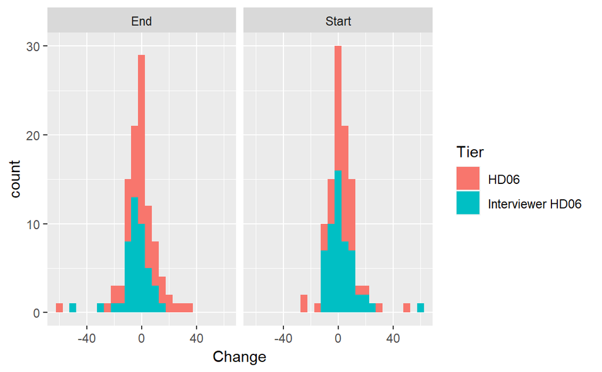

Instead, it looks like it’s just whichever boundary comes first:

| Tier | ANNOTATION_ID | Boundary | Orig | Output | Change |
| --- | --- | --- | --- | --- | --- |
| Interviewer HD06 | a10 | Start | 9300 | 9362 | 62 |
| HD06 | a7 | End | 9362 | 9300 | -62 |
| Interviewer HD06 | a17 | Start | 15310 | 15311 | 1 |
| HD06 | a15 | End | 15311 | 15310 | -1 |
| HD06 | a18 | Start | 20668 | 20717 | 49 |
| Interviewer HD06 | a19 | End | 20717 | 20668 | -49 |
| HD06 | a24 | End | 37392 | 37394 | 2 |
| HD06 | a37 | End | 47378 | 47401 | 23 |
| HD06 | a58 | End | 72924 | 72927 | 3 |
| HD06 | a62 | Start | 79384 | 79383 | -1 |

[output cut: 198 more lines]

That said, I’m surprised that *both* the boundaries move in a lot of these. In the first two rows, a 62ms overlap turns into a 62ms gap. But I want a 62ms overlap to turn into a 0ms gap. Maybe that’s because of the vectorized implementation; the Southland ones used a for-loop.

# 3 Why the gap? Troubleshoot `fixOverlaps()`

Try walking thru what `fixOverlaps()` does

This is like a single `times[[.x]]` element within the `map()` in `overlapsIssues()`—the thing that goes into each `fixOverlaps()`

```r
dfEAF <- eafs_to_df("../APLS Elan File Checker/tests/shinytest/step3/HD06-1_GoodOnly.eaf",
                    singleDF=FALSE) %>%
  pluck(1)
dfEAF %>% str(1)
```

```
List of 2
 $ HD06            : tibble [490 × 5] (S3: tbl_df/tbl/data.frame)
 $ Interviewer HD06: tibble [285 × 5] (S3: tbl_df/tbl/data.frame)
```

```r
eaflist <- c(Orig = "../APLS Elan File Checker/tests/shinytest/step3/HD06-1_GoodOnly.eaf") %>%
  map(read_xml)
eaflist %>% str(1)
```

```
List of 1
 $ Orig:List of 2
  ..- attr(*, "class")= chr [1:2] "xml_document" "xml_node"
```

```r
fixOverlaps(dfEAF, eaflist, "Orig")
```

```
iters: 1
nrow(overlapsPre): 110 98
nrow(overlapsPost): 0 0
```

| ANNOTATION_ID | Side | TIME_SLOT_REF | Time | ANNOTATION_ID_overlapped | TIME_SLOT_REF1_overlapped | TIME_SLOT_REF2_overlapped | Start_overlapped | End_overlapped | StartDiff | EndDiff | CloseEnough | NewTS | NodePath | Resolved |
| --- | --- | --- | --- | --- | --- | --- | --- | --- | --- | --- | --- | --- | --- | --- |

```
$`Interviewer HD06`
```

| ANNOTATION_ID | Side | TIME_SLOT_REF | Time | ANNOTATION_ID_overlapped | TIME_SLOT_REF1_overlapped | TIME_SLOT_REF2_overlapped | Start_overlapped | End_overlapped | StartDiff | EndDiff | CloseEnough | NewTS | NodePath | Resolved |
| --- | --- | --- | --- | --- | --- | --- | --- | --- | --- | --- | --- | --- | --- | --- |

```
NA
```

Here’s what we get for `overlapsInit` w/in `fixOverlaps()`

```r
dfEAF %>%
  names() %>%
  set_names(., .) %>%
  map(findOverlapsTier, dfEAF)
```

| ANNOTATION_ID | Side | TIME_SLOT_REF | Time | ANNOTATION_ID_overlapped | TIME_SLOT_REF1_overlapped | TIME_SLOT_REF2_overlapped | Start_overlapped | End_overlapped | StartDiff | EndDiff | CloseEnough | NewTS | NodePath |
| --- | --- | --- | --- | --- | --- | --- | --- | --- | --- | --- | --- | --- | --- |
| a7 | 2 | ts13 | 9362 | a10 | ts12 | ts14 | 9300 | 9897 | 62 | 535 | TRUE | ts12 | //ALIGNABLE_ANNOTATION[@ANNOTATION_ID='a7'] |
| a15 | 2 | ts33 | 15311 | a17 | ts32 | ts34 | 15310 | 17812 | 1 | 2501 | TRUE | ts32 | //ALIGNABLE_ANNOTATION[@ANNOTATION_ID='a15'] |
| a18 | 1 | ts36 | 20668 | a19 | ts35 | ts37 | 17832 | 20717 | 2836 | 49 | TRUE | ts37 | //ALIGNABLE_ANNOTATION[@ANNOTATION_ID='a18'] |
| a24 | 2 | ts55 | 37392 | a32 | ts53 | ts56 | 37084 | 37394 | 308 | 2 | TRUE | ts56 | //ALIGNABLE_ANNOTATION[@ANNOTATION_ID='a24'] |
| a37 | 2 | ts73 | 47378 | a39 | ts72 | ts74 | 46899 | 47401 | 479 | 23 | TRUE | ts74 | //ALIGNABLE_ANNOTATION[@ANNOTATION_ID='a37'] |
| a58 | 2 | ts97 | 72924 | a64 | ts96 | ts98 | 72054 | 72927 | 870 | 3 | TRUE | ts98 | //ALIGNABLE_ANNOTATION[@ANNOTATION_ID='a58'] |
| a62 | 1 | ts104 | 79384 | a65 | ts102 | ts105 | 79383 | 80448 | 1 | 1064 | TRUE | ts102 | //ALIGNABLE_ANNOTATION[@ANNOTATION_ID='a62'] |
| a71 | 2 | ts122 | 107782 | a83 | ts120 | ts123 | 106949 | 107784 | 833 | 2 | TRUE | ts123 | //ALIGNABLE_ANNOTATION[@ANNOTATION_ID='a71'] |
| a72 | 1 | ts121 | 107782 | a83 | ts120 | ts123 | 106949 | 107784 | 833 | 2 | TRUE | ts123 | //ALIGNABLE_ANNOTATION[@ANNOTATION_ID='a72'] |
| a99 | 2 | ts155 | 153781 | a111 | ts154 | ts156 | 153779 | 154357 | 2 | 576 | TRUE | ts154 | //ALIGNABLE_ANNOTATION[@ANNOTATION_ID='a99'] |

[output cut: 100 more lines]

```
$`Interviewer HD06`
```

| ANNOTATION_ID | Side | TIME_SLOT_REF | Time | ANNOTATION_ID_overlapped | TIME_SLOT_REF1_overlapped | TIME_SLOT_REF2_overlapped | Start_overlapped | End_overlapped | StartDiff | EndDiff | CloseEnough | NewTS | NodePath |
| --- | --- | --- | --- | --- | --- | --- | --- | --- | --- | --- | --- | --- | --- |
| a10 | 1 | ts12 | 9300 | a7 | ts11 | ts13 | 8305 | 9362 | 995 | 62 | TRUE | ts13 | //ALIGNABLE_ANNOTATION[@ANNOTATION_ID='a10'] |
| a17 | 1 | ts32 | 15310 | a15 | ts31 | ts33 | 14345 | 15311 | 965 | 1 | TRUE | ts33 | //ALIGNABLE_ANNOTATION[@ANNOTATION_ID='a17'] |
| a19 | 2 | ts37 | 20717 | a18 | ts36 | ts38 | 20668 | 21932 | 49 | 1215 | TRUE | ts36 | //ALIGNABLE_ANNOTATION[@ANNOTATION_ID='a19'] |
| a83 | 1 | ts120 | 106949 | a71 | ts119 | ts122 | 106948 | 107782 | 1 | 833 | TRUE | ts119 | //ALIGNABLE_ANNOTATION[@ANNOTATION_ID='a83'] |
| a83 | 2 | ts123 | 107784 | a72 | ts121 | ts124 | 107782 | 110284 | 2 | 2500 | TRUE | ts121 | //ALIGNABLE_ANNOTATION[@ANNOTATION_ID='a83'] |
| a88 | 1 | ts138 | 128276 | a76 | ts137 | ts140 | 128272 | 129174 | 4 | 898 | TRUE | ts137 | //ALIGNABLE_ANNOTATION[@ANNOTATION_ID='a88'] |
| a109 | 1 | ts144 | 130557 | a90 | ts143 | ts146 | 130556 | 131249 | 1 | 692 | TRUE | ts143 | //ALIGNABLE_ANNOTATION[@ANNOTATION_ID='a109'] |
| a111 | 1 | ts154 | 153779 | a99 | ts153 | ts155 | 148047 | 153781 | 5732 | 2 | TRUE | ts155 | //ALIGNABLE_ANNOTATION[@ANNOTATION_ID='a111'] |
| a143 | 2 | ts209 | 203133 | a135 | ts207 | ts210 | 201786 | 203144 | 1347 | 11 | TRUE | ts210 | //ALIGNABLE_ANNOTATION[@ANNOTATION_ID='a143'] |
| a154 | 1 | ts224 | 220861 | a906 | ts223 | ts225 | 220423 | 220862 | 438 | 1 | TRUE | ts225 | //ALIGNABLE_ANNOTATION[@ANNOTATION_ID='a154'] |

[output cut: 88 more lines]

```r
dfEAF %>%
  findOverlaps()
```

| ANNOTATION_ID | Side | TIME_SLOT_REF | Time | ANNOTATION_ID_overlapped | TIME_SLOT_REF1_overlapped | TIME_SLOT_REF2_overlapped | Start_overlapped | End_overlapped | StartDiff | EndDiff | CloseEnough | NewTS | NodePath |
| --- | --- | --- | --- | --- | --- | --- | --- | --- | --- | --- | --- | --- | --- |
| a7 | 2 | ts13 | 9362 | a10 | ts12 | ts14 | 9300 | 9897 | 62 | 535 | TRUE | ts12 | //ALIGNABLE_ANNOTATION[@ANNOTATION_ID='a7'] |
| a15 | 2 | ts33 | 15311 | a17 | ts32 | ts34 | 15310 | 17812 | 1 | 2501 | TRUE | ts32 | //ALIGNABLE_ANNOTATION[@ANNOTATION_ID='a15'] |
| a18 | 1 | ts36 | 20668 | a19 | ts35 | ts37 | 17832 | 20717 | 2836 | 49 | TRUE | ts37 | //ALIGNABLE_ANNOTATION[@ANNOTATION_ID='a18'] |
| a24 | 2 | ts55 | 37392 | a32 | ts53 | ts56 | 37084 | 37394 | 308 | 2 | TRUE | ts56 | //ALIGNABLE_ANNOTATION[@ANNOTATION_ID='a24'] |
| a37 | 2 | ts73 | 47378 | a39 | ts72 | ts74 | 46899 | 47401 | 479 | 23 | TRUE | ts74 | //ALIGNABLE_ANNOTATION[@ANNOTATION_ID='a37'] |
| a58 | 2 | ts97 | 72924 | a64 | ts96 | ts98 | 72054 | 72927 | 870 | 3 | TRUE | ts98 | //ALIGNABLE_ANNOTATION[@ANNOTATION_ID='a58'] |
| a62 | 1 | ts104 | 79384 | a65 | ts102 | ts105 | 79383 | 80448 | 1 | 1064 | TRUE | ts102 | //ALIGNABLE_ANNOTATION[@ANNOTATION_ID='a62'] |
| a71 | 2 | ts122 | 107782 | a83 | ts120 | ts123 | 106949 | 107784 | 833 | 2 | TRUE | ts123 | //ALIGNABLE_ANNOTATION[@ANNOTATION_ID='a71'] |
| a72 | 1 | ts121 | 107782 | a83 | ts120 | ts123 | 106949 | 107784 | 833 | 2 | TRUE | ts123 | //ALIGNABLE_ANNOTATION[@ANNOTATION_ID='a72'] |
| a99 | 2 | ts155 | 153781 | a111 | ts154 | ts156 | 153779 | 154357 | 2 | 576 | TRUE | ts154 | //ALIGNABLE_ANNOTATION[@ANNOTATION_ID='a99'] |

[output cut: 100 more lines]

```
$`Interviewer HD06`
```

| ANNOTATION_ID | Side | TIME_SLOT_REF | Time | ANNOTATION_ID_overlapped | TIME_SLOT_REF1_overlapped | TIME_SLOT_REF2_overlapped | Start_overlapped | End_overlapped | StartDiff | EndDiff | CloseEnough | NewTS | NodePath |
| --- | --- | --- | --- | --- | --- | --- | --- | --- | --- | --- | --- | --- | --- |
| a10 | 1 | ts12 | 9300 | a7 | ts11 | ts13 | 8305 | 9362 | 995 | 62 | TRUE | ts13 | //ALIGNABLE_ANNOTATION[@ANNOTATION_ID='a10'] |
| a17 | 1 | ts32 | 15310 | a15 | ts31 | ts33 | 14345 | 15311 | 965 | 1 | TRUE | ts33 | //ALIGNABLE_ANNOTATION[@ANNOTATION_ID='a17'] |
| a19 | 2 | ts37 | 20717 | a18 | ts36 | ts38 | 20668 | 21932 | 49 | 1215 | TRUE | ts36 | //ALIGNABLE_ANNOTATION[@ANNOTATION_ID='a19'] |
| a83 | 1 | ts120 | 106949 | a71 | ts119 | ts122 | 106948 | 107782 | 1 | 833 | TRUE | ts119 | //ALIGNABLE_ANNOTATION[@ANNOTATION_ID='a83'] |
| a83 | 2 | ts123 | 107784 | a72 | ts121 | ts124 | 107782 | 110284 | 2 | 2500 | TRUE | ts121 | //ALIGNABLE_ANNOTATION[@ANNOTATION_ID='a83'] |
| a88 | 1 | ts138 | 128276 | a76 | ts137 | ts140 | 128272 | 129174 | 4 | 898 | TRUE | ts137 | //ALIGNABLE_ANNOTATION[@ANNOTATION_ID='a88'] |
| a109 | 1 | ts144 | 130557 | a90 | ts143 | ts146 | 130556 | 131249 | 1 | 692 | TRUE | ts143 | //ALIGNABLE_ANNOTATION[@ANNOTATION_ID='a109'] |
| a111 | 1 | ts154 | 153779 | a99 | ts153 | ts155 | 148047 | 153781 | 5732 | 2 | TRUE | ts155 | //ALIGNABLE_ANNOTATION[@ANNOTATION_ID='a111'] |
| a143 | 2 | ts209 | 203133 | a135 | ts207 | ts210 | 201786 | 203144 | 1347 | 11 | TRUE | ts210 | //ALIGNABLE_ANNOTATION[@ANNOTATION_ID='a143'] |
| a154 | 1 | ts224 | 220861 | a906 | ts223 | ts225 | 220423 | 220862 | 438 | 1 | TRUE | ts225 | //ALIGNABLE_ANNOTATION[@ANNOTATION_ID='a154'] |

[output cut: 88 more lines]

```
NA
```

It turns out the code doesn’t actually call `findOverlaps()`. Whoops! Just changed that

At first, `overlapsPost` is just `overlapsInit`

```r
overlapsPost <-
  dfEAF %>%
  findOverlaps()
##Any >0 triggers the while loop
map_int(overlapsPost, nrow)
```

```
            HD06 Interviewer HD06
             110               98
```

Then Post is just mapping Pre over `fixOverlapsTier()`:

```r
overlapsPre %>%
  map(fixOverlapsTier, eaflist, "Orig")
```

| ANNOTATION_ID | Side | TIME_SLOT_REF | Time | ANNOTATION_ID_overlapped | TIME_SLOT_REF1_overlapped | TIME_SLOT_REF2_overlapped | Start_overlapped | End_overlapped | StartDiff | EndDiff | CloseEnough | NewTS | NodePath | Resolved |
| --- | --- | --- | --- | --- | --- | --- | --- | --- | --- | --- | --- | --- | --- | --- |
| a7 | 2 | ts13 | 9362 | a10 | ts12 | ts14 | 9300 | 9897 | 62 | 535 | TRUE | ts12 | //ALIGNABLE_ANNOTATION[@ANNOTATION_ID='a7'] | TRUE |
| a15 | 2 | ts33 | 15311 | a17 | ts32 | ts34 | 15310 | 17812 | 1 | 2501 | TRUE | ts32 | //ALIGNABLE_ANNOTATION[@ANNOTATION_ID='a15'] | TRUE |
| a18 | 1 | ts36 | 20668 | a19 | ts35 | ts37 | 17832 | 20717 | 2836 | 49 | TRUE | ts37 | //ALIGNABLE_ANNOTATION[@ANNOTATION_ID='a18'] | TRUE |
| a24 | 2 | ts55 | 37392 | a32 | ts53 | ts56 | 37084 | 37394 | 308 | 2 | TRUE | ts56 | //ALIGNABLE_ANNOTATION[@ANNOTATION_ID='a24'] | TRUE |
| a37 | 2 | ts73 | 47378 | a39 | ts72 | ts74 | 46899 | 47401 | 479 | 23 | TRUE | ts74 | //ALIGNABLE_ANNOTATION[@ANNOTATION_ID='a37'] | TRUE |
| a58 | 2 | ts97 | 72924 | a64 | ts96 | ts98 | 72054 | 72927 | 870 | 3 | TRUE | ts98 | //ALIGNABLE_ANNOTATION[@ANNOTATION_ID='a58'] | TRUE |
| a62 | 1 | ts104 | 79384 | a65 | ts102 | ts105 | 79383 | 80448 | 1 | 1064 | TRUE | ts102 | //ALIGNABLE_ANNOTATION[@ANNOTATION_ID='a62'] | TRUE |
| a71 | 2 | ts122 | 107782 | a83 | ts120 | ts123 | 106949 | 107784 | 833 | 2 | TRUE | ts123 | //ALIGNABLE_ANNOTATION[@ANNOTATION_ID='a71'] | TRUE |
| a72 | 1 | ts121 | 107782 | a83 | ts120 | ts123 | 106949 | 107784 | 833 | 2 | TRUE | ts123 | //ALIGNABLE_ANNOTATION[@ANNOTATION_ID='a72'] | TRUE |
| a99 | 2 | ts155 | 153781 | a111 | ts154 | ts156 | 153779 | 154357 | 2 | 576 | TRUE | ts154 | //ALIGNABLE_ANNOTATION[@ANNOTATION_ID='a99'] | TRUE |

[output cut: 100 more lines]

```
$`Interviewer HD06`
```

| ANNOTATION_ID | Side | TIME_SLOT_REF | Time | ANNOTATION_ID_overlapped | TIME_SLOT_REF1_overlapped | TIME_SLOT_REF2_overlapped | Start_overlapped | End_overlapped | StartDiff | EndDiff | CloseEnough | NewTS | NodePath | Resolved |
| --- | --- | --- | --- | --- | --- | --- | --- | --- | --- | --- | --- | --- | --- | --- |
| a10 | 1 | ts12 | 9300 | a7 | ts11 | ts13 | 8305 | 9362 | 995 | 62 | TRUE | ts13 | //ALIGNABLE_ANNOTATION[@ANNOTATION_ID='a10'] | TRUE |
| a17 | 1 | ts32 | 15310 | a15 | ts31 | ts33 | 14345 | 15311 | 965 | 1 | TRUE | ts33 | //ALIGNABLE_ANNOTATION[@ANNOTATION_ID='a17'] | TRUE |
| a19 | 2 | ts37 | 20717 | a18 | ts36 | ts38 | 20668 | 21932 | 49 | 1215 | TRUE | ts36 | //ALIGNABLE_ANNOTATION[@ANNOTATION_ID='a19'] | TRUE |
| a83 | 1 | ts120 | 106949 | a71 | ts119 | ts122 | 106948 | 107782 | 1 | 833 | TRUE | ts119 | //ALIGNABLE_ANNOTATION[@ANNOTATION_ID='a83'] | TRUE |
| a83 | 2 | ts123 | 107784 | a72 | ts121 | ts124 | 107782 | 110284 | 2 | 2500 | TRUE | ts121 | //ALIGNABLE_ANNOTATION[@ANNOTATION_ID='a83'] | TRUE |
| a88 | 1 | ts138 | 128276 | a76 | ts137 | ts140 | 128272 | 129174 | 4 | 898 | TRUE | ts137 | //ALIGNABLE_ANNOTATION[@ANNOTATION_ID='a88'] | TRUE |
| a109 | 1 | ts144 | 130557 | a90 | ts143 | ts146 | 130556 | 131249 | 1 | 692 | TRUE | ts143 | //ALIGNABLE_ANNOTATION[@ANNOTATION_ID='a109'] | TRUE |
| a111 | 1 | ts154 | 153779 | a99 | ts153 | ts155 | 148047 | 153781 | 5732 | 2 | TRUE | ts155 | //ALIGNABLE_ANNOTATION[@ANNOTATION_ID='a111'] | TRUE |
| a143 | 2 | ts209 | 203133 | a135 | ts207 | ts210 | 201786 | 203144 | 1347 | 11 | TRUE | ts210 | //ALIGNABLE_ANNOTATION[@ANNOTATION_ID='a143'] | TRUE |
| a154 | 1 | ts224 | 220861 | a906 | ts223 | ts225 | 220423 | 220862 | 438 | 1 | TRUE | ts225 | //ALIGNABLE_ANNOTATION[@ANNOTATION_ID='a154'] | TRUE |

[output cut: 88 more lines]

```r
overlapsPre %>%
  map(fixOverlapsTier, eaflist, "Orig") %>%
  map("Resolved")
```

```
$HD06
  [1] TRUE TRUE TRUE TRUE TRUE TRUE TRUE TRUE TRUE TRUE TRUE TRUE TRUE TRUE TRUE TRUE TRUE TRUE TRUE TRUE TRUE
 [22] TRUE TRUE TRUE TRUE TRUE TRUE TRUE TRUE TRUE TRUE TRUE TRUE TRUE TRUE TRUE TRUE TRUE TRUE TRUE TRUE TRUE
 [43] TRUE TRUE TRUE TRUE TRUE TRUE TRUE TRUE TRUE TRUE TRUE TRUE TRUE TRUE TRUE TRUE TRUE TRUE TRUE TRUE TRUE
 [64] TRUE TRUE TRUE TRUE TRUE TRUE TRUE TRUE TRUE TRUE TRUE TRUE TRUE TRUE TRUE TRUE TRUE TRUE TRUE TRUE TRUE
 [85] TRUE TRUE TRUE TRUE TRUE TRUE TRUE TRUE TRUE TRUE TRUE TRUE TRUE TRUE TRUE TRUE TRUE TRUE TRUE TRUE TRUE
[106] TRUE TRUE TRUE TRUE TRUE

$`Interviewer HD06`
 [1] TRUE TRUE TRUE TRUE TRUE TRUE TRUE TRUE TRUE TRUE TRUE TRUE TRUE TRUE TRUE TRUE TRUE TRUE TRUE TRUE TRUE
[22] TRUE TRUE TRUE TRUE TRUE TRUE TRUE TRUE TRUE TRUE TRUE TRUE TRUE TRUE TRUE TRUE TRUE TRUE TRUE TRUE TRUE
[43] TRUE TRUE TRUE TRUE TRUE TRUE TRUE TRUE TRUE TRUE TRUE TRUE TRUE TRUE TRUE TRUE TRUE TRUE TRUE TRUE TRUE
[64] TRUE TRUE TRUE TRUE TRUE TRUE TRUE TRUE TRUE TRUE TRUE TRUE TRUE TRUE TRUE TRUE TRUE TRUE TRUE TRUE TRUE
[85] TRUE TRUE TRUE TRUE TRUE TRUE TRUE TRUE TRUE TRUE TRUE TRUE TRUE TRUE
```

And then we get the gap problem:

| File | Tier | ANNOTATION_ID | TIME_SLOT_REF1 | TIME_SLOT_REF2 | Start | End |
| --- | --- | --- | --- | --- | --- | --- |
| Orig | HD06 | a7 | ts11 | ts12 | 8305 | 9300 |
| Orig | Interviewer HD06 | a10 | ts13 | ts14 | 9362 | 9897 |

Double-check: is it modifying eaflist in-situ? Yup!

```r
old_eaflist <- eaflist
eaflist <- c(Orig = "../APLS Elan File Checker/tests/shinytest/step3/HD06-1_GoodOnly.eaf") %>%
  map(read_xml)
identical(old_eaflist, eaflist)
```

```
[1] FALSE
```

```r
all.equal(old_eaflist %>% xmllist_to_df(),
          eaflist %>% xmllist_to_df())
```

```
[1] "Component “TIME_SLOT_REF1”: 104 string mismatches"
[2] "Component “TIME_SLOT_REF2”: 104 string mismatches"
[3] "Component “Start”: Mean relative difference: 6.644029e-06"
[4] "Component “End”: Mean relative difference: 7.794373e-06"
```

```r
eaflist %>%
  xmllist_to_df() %>%
  filter(ANNOTATION_ID %in% c("a7", "a10"))
```

| File | Tier | ANNOTATION_ID | TIME_SLOT_REF1 | TIME_SLOT_REF2 | Start | End |
| --- | --- | --- | --- | --- | --- | --- |
| Orig | HD06 | a7 | ts11 | ts13 | 8305 | 9362 |
| Orig | Interviewer HD06 | a10 | ts12 | ts14 | 9300 | 9897 |

How would that work in a for-loop instead of `map()`?

```r
counter <- 1
oPost <- list()
for (oP in overlapsPre) {
  oPost[[counter]] <- fixOverlapsTier(oP, eaflist, "Orig")
  counter <- counter + 1
}
oPost
```

| ANNOTATION_ID | Side | TIME_SLOT_REF | Time | ANNOTATION_ID_overlapped | TIME_SLOT_REF1_overlapped | TIME_SLOT_REF2_overlapped | Start_overlapped | End_overlapped | StartDiff | EndDiff | CloseEnough | NewTS | NodePath | Resolved |
| --- | --- | --- | --- | --- | --- | --- | --- | --- | --- | --- | --- | --- | --- | --- |
| a7 | 2 | ts13 | 9362 | a10 | ts12 | ts14 | 9300 | 9897 | 62 | 535 | TRUE | ts12 | //ALIGNABLE_ANNOTATION[@ANNOTATION_ID='a7'] | TRUE |
| a15 | 2 | ts33 | 15311 | a17 | ts32 | ts34 | 15310 | 17812 | 1 | 2501 | TRUE | ts32 | //ALIGNABLE_ANNOTATION[@ANNOTATION_ID='a15'] | TRUE |
| a18 | 1 | ts36 | 20668 | a19 | ts35 | ts37 | 17832 | 20717 | 2836 | 49 | TRUE | ts37 | //ALIGNABLE_ANNOTATION[@ANNOTATION_ID='a18'] | TRUE |
| a24 | 2 | ts55 | 37392 | a32 | ts53 | ts56 | 37084 | 37394 | 308 | 2 | TRUE | ts56 | //ALIGNABLE_ANNOTATION[@ANNOTATION_ID='a24'] | TRUE |
| a37 | 2 | ts73 | 47378 | a39 | ts72 | ts74 | 46899 | 47401 | 479 | 23 | TRUE | ts74 | //ALIGNABLE_ANNOTATION[@ANNOTATION_ID='a37'] | TRUE |
| a58 | 2 | ts97 | 72924 | a64 | ts96 | ts98 | 72054 | 72927 | 870 | 3 | TRUE | ts98 | //ALIGNABLE_ANNOTATION[@ANNOTATION_ID='a58'] | TRUE |
| a62 | 1 | ts104 | 79384 | a65 | ts102 | ts105 | 79383 | 80448 | 1 | 1064 | TRUE | ts102 | //ALIGNABLE_ANNOTATION[@ANNOTATION_ID='a62'] | TRUE |
| a71 | 2 | ts122 | 107782 | a83 | ts120 | ts123 | 106949 | 107784 | 833 | 2 | TRUE | ts123 | //ALIGNABLE_ANNOTATION[@ANNOTATION_ID='a71'] | TRUE |
| a72 | 1 | ts121 | 107782 | a83 | ts120 | ts123 | 106949 | 107784 | 833 | 2 | TRUE | ts123 | //ALIGNABLE_ANNOTATION[@ANNOTATION_ID='a72'] | TRUE |
| a99 | 2 | ts155 | 153781 | a111 | ts154 | ts156 | 153779 | 154357 | 2 | 576 | TRUE | ts154 | //ALIGNABLE_ANNOTATION[@ANNOTATION_ID='a99'] | TRUE |

[output cut: 100 more lines]

| ANNOTATION_ID | Side | TIME_SLOT_REF | Time | ANNOTATION_ID_overlapped | TIME_SLOT_REF1_overlapped | TIME_SLOT_REF2_overlapped | Start_overlapped | End_overlapped | StartDiff | EndDiff | CloseEnough | NewTS | NodePath | Resolved |
| --- | --- | --- | --- | --- | --- | --- | --- | --- | --- | --- | --- | --- | --- | --- |
| a10 | 1 | ts12 | 9300 | a7 | ts11 | ts13 | 8305 | 9362 | 995 | 62 | TRUE | ts13 | //ALIGNABLE_ANNOTATION[@ANNOTATION_ID='a10'] | TRUE |
| a17 | 1 | ts32 | 15310 | a15 | ts31 | ts33 | 14345 | 15311 | 965 | 1 | TRUE | ts33 | //ALIGNABLE_ANNOTATION[@ANNOTATION_ID='a17'] | TRUE |
| a19 | 2 | ts37 | 20717 | a18 | ts36 | ts38 | 20668 | 21932 | 49 | 1215 | TRUE | ts36 | //ALIGNABLE_ANNOTATION[@ANNOTATION_ID='a19'] | TRUE |
| a83 | 1 | ts120 | 106949 | a71 | ts119 | ts122 | 106948 | 107782 | 1 | 833 | TRUE | ts119 | //ALIGNABLE_ANNOTATION[@ANNOTATION_ID='a83'] | TRUE |
| a83 | 2 | ts123 | 107784 | a72 | ts121 | ts124 | 107782 | 110284 | 2 | 2500 | TRUE | ts121 | //ALIGNABLE_ANNOTATION[@ANNOTATION_ID='a83'] | TRUE |
| a88 | 1 | ts138 | 128276 | a76 | ts137 | ts140 | 128272 | 129174 | 4 | 898 | TRUE | ts137 | //ALIGNABLE_ANNOTATION[@ANNOTATION_ID='a88'] | TRUE |
| a109 | 1 | ts144 | 130557 | a90 | ts143 | ts146 | 130556 | 131249 | 1 | 692 | TRUE | ts143 | //ALIGNABLE_ANNOTATION[@ANNOTATION_ID='a109'] | TRUE |
| a111 | 1 | ts154 | 153779 | a99 | ts153 | ts155 | 148047 | 153781 | 5732 | 2 | TRUE | ts155 | //ALIGNABLE_ANNOTATION[@ANNOTATION_ID='a111'] | TRUE |
| a143 | 2 | ts209 | 203133 | a135 | ts207 | ts210 | 201786 | 203144 | 1347 | 11 | TRUE | ts210 | //ALIGNABLE_ANNOTATION[@ANNOTATION_ID='a143'] | TRUE |
| a154 | 1 | ts224 | 220861 | a906 | ts223 | ts225 | 220423 | 220862 | 438 | 1 | TRUE | ts225 | //ALIGNABLE_ANNOTATION[@ANNOTATION_ID='a154'] | TRUE |

[output cut: 88 more lines]

```r
eaflist %>%
  xmllist_to_df() %>%
  filter(ANNOTATION_ID %in% c("a7", "a10"))
```

| File | Tier | ANNOTATION_ID | TIME_SLOT_REF1 | TIME_SLOT_REF2 | Start | End |
| --- | --- | --- | --- | --- | --- | --- |
| Orig | HD06 | a7 | ts11 | ts12 | 8305 | 9300 |
| Orig | Interviewer HD06 | a10 | ts13 | ts14 | 9362 | 9897 |

It reproduces the gap issue

# 4 A different approach to `fixOverlaps()`

Right now the process is:

```
for each file:
    for each tier:
        find overlaps
    for each tier:
        fix overlaps
```

Maybe the process should be:

```
for each file:
    for each tier:
        find overlaps
        fix overlaps
```

In other words, overlaps get re-assessed after each tier

So reload eaflist (no need to reload dfEAF because it’s unchanged)

```r
eaflist <- c(Orig = "../APLS Elan File Checker/tests/shinytest/step3/HD06-1_GoodOnly.eaf") %>%
  map(read_xml)
eaflist %>%
  xmllist_to_df() %>%
  filter(ANNOTATION_ID %in% c("a7", "a10"))
```

| File | Tier | ANNOTATION_ID | TIME_SLOT_REF1 | TIME_SLOT_REF2 | Start | End |
| --- | --- | --- | --- | --- | --- | --- |
| Orig | HD06 | a7 | ts11 | ts13 | 8305 | 9362 |
| Orig | Interviewer HD06 | a10 | ts12 | ts14 | 9300 | 9897 |

## 4.1 Attempt setting HD06 to NA

Now pretend there are no overlaps to be resolved for HD06:

```r
overlapsPre <- overlapsPost
overlapsPre$HD06 <- overlapsPre$HD06 %>%
  filter(is.na(ANNOTATION_ID))
overlapsPre %>% str(1)
```

```
List of 2
 $ HD06            : tibble [0 × 14] (S3: tbl_df/tbl/data.frame)
 $ Interviewer HD06: tibble [98 × 14] (S3: tbl_df/tbl/data.frame)
```

```r
overlapsPre %>%
  map(fixOverlapsTier, eaflist, "Orig") %>%
  map("Resolved")
```

```
$HD06
NULL

$`Interviewer HD06`
 [1] TRUE TRUE TRUE TRUE TRUE TRUE TRUE TRUE TRUE TRUE TRUE TRUE TRUE TRUE TRUE TRUE TRUE TRUE TRUE TRUE TRUE
[22] TRUE TRUE TRUE TRUE TRUE TRUE TRUE TRUE TRUE TRUE TRUE TRUE TRUE TRUE TRUE TRUE TRUE TRUE TRUE TRUE TRUE
[43] TRUE TRUE TRUE TRUE TRUE TRUE TRUE TRUE TRUE TRUE TRUE TRUE TRUE TRUE TRUE TRUE TRUE TRUE TRUE TRUE TRUE
[64] TRUE TRUE TRUE TRUE TRUE TRUE TRUE TRUE TRUE TRUE TRUE TRUE TRUE TRUE TRUE TRUE TRUE TRUE TRUE TRUE TRUE
[85] TRUE TRUE TRUE TRUE TRUE TRUE TRUE TRUE TRUE TRUE TRUE TRUE TRUE TRUE
```

Drumroll please!

| File | Tier | ANNOTATION_ID | TIME_SLOT_REF1 | TIME_SLOT_REF2 | Start | End |
| --- | --- | --- | --- | --- | --- | --- |
| Orig | HD06 | a7 | ts11 | ts13 | 8305 | 9362 |
| Orig | Interviewer HD06 | a10 | ts13 | ts14 | 9362 | 9897 |

How many overlaps remain?

```r
eaflist %>%
  xmllist_to_df(singleDF=F) %>%
  pluck("Orig") %>%
  findOverlaps()
```

| ANNOTATION_ID | Side | TIME_SLOT_REF | Time | ANNOTATION_ID_overlapped | TIME_SLOT_REF1_overlapped | TIME_SLOT_REF2_overlapped | Start_overlapped | End_overlapped | StartDiff | EndDiff | CloseEnough | NewTS | NodePath |
| --- | --- | --- | --- | --- | --- | --- | --- | --- | --- | --- | --- | --- | --- |
| a24 | 2 | ts55 | 37392 | a32 | ts53 | ts56 | 37084 | 37394 | 308 | 2 | TRUE | ts56 | //ALIGNABLE_ANNOTATION[@ANNOTATION_ID='a24'] |
| a37 | 2 | ts73 | 47378 | a39 | ts72 | ts74 | 46899 | 47401 | 479 | 23 | TRUE | ts74 | //ALIGNABLE_ANNOTATION[@ANNOTATION_ID='a37'] |
| a58 | 2 | ts97 | 72924 | a64 | ts96 | ts98 | 72054 | 72927 | 870 | 3 | TRUE | ts98 | //ALIGNABLE_ANNOTATION[@ANNOTATION_ID='a58'] |
| a62 | 1 | ts104 | 79384 | a65 | ts102 | ts105 | 79383 | 80448 | 1 | 1064 | TRUE | ts102 | //ALIGNABLE_ANNOTATION[@ANNOTATION_ID='a62'] |
| a118 | 2 | ts173 | 175146 | a126 | ts171 | ts174 | 174478 | 175149 | 668 | 3 | TRUE | ts174 | //ALIGNABLE_ANNOTATION[@ANNOTATION_ID='a118'] |
| a124 | 1 | ts186 | 183940 | a129 | ts185 | ts188 | 183936 | 185133 | 4 | 1193 | TRUE | ts185 | //ALIGNABLE_ANNOTATION[@ANNOTATION_ID='a124'] |
| a132 | 2 | ts197 | 191522 | a140 | ts195 | ts198 | 190941 | 191523 | 581 | 1 | TRUE | ts198 | //ALIGNABLE_ANNOTATION[@ANNOTATION_ID='a132'] |
| a172 | 2 | ts257 | 276044 | a181 | ts255 | ts258 | 275499 | 276046 | 545 | 2 | TRUE | ts258 | //ALIGNABLE_ANNOTATION[@ANNOTATION_ID='a172'] |
| a176 | 2 | ts273 | 288697 | a185 | ts270 | ts274 | 288252 | 288710 | 445 | 13 | TRUE | ts274 | //ALIGNABLE_ANNOTATION[@ANNOTATION_ID='a176'] |
| a207 | 1 | ts324 | 380894 | a214 | ts323 | ts326 | 380881 | 381363 | 13 | 469 | TRUE | ts323 | //ALIGNABLE_ANNOTATION[@ANNOTATION_ID='a207'] |

[output cut: 13 more lines]

```
$`Interviewer HD06`
```

| ANNOTATION_ID | Side | TIME_SLOT_REF | Time | ANNOTATION_ID_overlapped | TIME_SLOT_REF1_overlapped | TIME_SLOT_REF2_overlapped | Start_overlapped | End_overlapped | StartDiff | EndDiff | CloseEnough | NewTS | NodePath |
| --- | --- | --- | --- | --- | --- | --- | --- | --- | --- | --- | --- | --- | --- |

```
NA
```

Try it the other way now

```r
eaflist <- c(Orig = "../APLS Elan File Checker/tests/shinytest/step3/HD06-1_GoodOnly.eaf") %>%
  map(read_xml)
overlapsPre <- overlapsPost
overlapsPre$`Interviewer HD06` <- overlapsPre$`Interviewer HD06` %>%
  filter(is.na(ANNOTATION_ID))
overlapsPre %>% str(1)
```

```
List of 2
 $ HD06            : tibble [110 × 14] (S3: tbl_df/tbl/data.frame)
 $ Interviewer HD06: tibble [0 × 14] (S3: tbl_df/tbl/data.frame)
```

```r
overlapsPre %>%
  map(fixOverlapsTier, eaflist, "Orig") %>%
  map("Resolved")
```

```
$HD06
  [1] TRUE TRUE TRUE TRUE TRUE TRUE TRUE TRUE TRUE TRUE TRUE TRUE TRUE TRUE TRUE TRUE TRUE TRUE TRUE TRUE TRUE
 [22] TRUE TRUE TRUE TRUE TRUE TRUE TRUE TRUE TRUE TRUE TRUE TRUE TRUE TRUE TRUE TRUE TRUE TRUE TRUE TRUE TRUE
 [43] TRUE TRUE TRUE TRUE TRUE TRUE TRUE TRUE TRUE TRUE TRUE TRUE TRUE TRUE TRUE TRUE TRUE TRUE TRUE TRUE TRUE
 [64] TRUE TRUE TRUE TRUE TRUE TRUE TRUE TRUE TRUE TRUE TRUE TRUE TRUE TRUE TRUE TRUE TRUE TRUE TRUE TRUE TRUE
 [85] TRUE TRUE TRUE TRUE TRUE TRUE TRUE TRUE TRUE TRUE TRUE TRUE TRUE TRUE TRUE TRUE TRUE TRUE TRUE TRUE TRUE
[106] TRUE TRUE TRUE TRUE TRUE

$`Interviewer HD06`
NULL
```

```r
eaflist %>%
  xmllist_to_df() %>%
  filter(ANNOTATION_ID %in% c("a7", "a10"))
```

| File | Tier | ANNOTATION_ID | TIME_SLOT_REF1 | TIME_SLOT_REF2 | Start | End |
| --- | --- | --- | --- | --- | --- | --- |
| Orig | HD06 | a7 | ts11 | ts12 | 8305 | 9300 |
| Orig | Interviewer HD06 | a10 | ts12 | ts14 | 9300 | 9897 |

## 4.2 Now both

Now what happens if I switch it?

I’ll probably have to introduce an overlapsMid or something to avoid name-clashing

```r
eaflist <- c(Orig = "../APLS Elan File Checker/tests/shinytest/step3/HD06-1_GoodOnly.eaf") %>%
  map(read_xml)
overlapsPre <- overlapsMid <- overlapsPost
overlapsMid$`Interviewer HD06` <- overlapsMid$`Interviewer HD06` %>%
  filter(is.na(ANNOTATION_ID))
##Go through another fixing round
overlapsPost$HD06 <-
  overlapsMid %>%
  map(fixOverlapsTier, eaflist, "Orig") %>%
  pluck("HD06") %>%
  filter(!Resolved)
overlapsMid <- overlapsPre
overlapsMid$HD06 <- overlapsMid$HD06 %>%
  filter(is.na(ANNOTATION_ID))
overlapsPost$`Interviewer HD06` <-
  overlapsMid %>%
  map(fixOverlapsTier, eaflist, "Orig") %>%
  pluck("Interviewer HD06") %>%
  filter(!Resolved)
eaflist %>%
  xmllist_to_df() %>%
  filter(ANNOTATION_ID %in% c("a7", "a10"))
```

| File | Tier | ANNOTATION_ID | TIME_SLOT_REF1 | TIME_SLOT_REF2 | Start | End |
| --- | --- | --- | --- | --- | --- | --- |
| Orig | HD06 | a7 | ts11 | ts12 | 8305 | 9300 |
| Orig | Interviewer HD06 | a10 | ts13 | ts14 | 9362 | 9897 |

```r
eaflist %>%
  xmllist_to_df(singleDF=F) %>%
  pluck("Orig") %>%
  findOverlaps()
```

| ANNOTATION_ID | Side | TIME_SLOT_REF | Time | ANNOTATION_ID_overlapped | TIME_SLOT_REF1_overlapped | TIME_SLOT_REF2_overlapped | Start_overlapped | End_overlapped | StartDiff | EndDiff | CloseEnough | NewTS | NodePath |
| --- | --- | --- | --- | --- | --- | --- | --- | --- | --- | --- | --- | --- | --- |
| a160 | 1 | ts229 | 226053 | a167 | ts228 | ts232 | 226050 | 228385 | 3 | 2332 | TRUE | ts228 | //ALIGNABLE_ANNOTATION[@ANNOTATION_ID='a160'] |
| a175 | 1 | ts265 | 286196 | a183 | ts264 | ts269 | 286190 | 287336 | 6 | 1140 | TRUE | ts264 | //ALIGNABLE_ANNOTATION[@ANNOTATION_ID='a175'] |
| a175 | 2 | ts268 | 287335 | a183 | ts264 | ts269 | 286190 | 287336 | 1145 | 1 | TRUE | ts269 | //ALIGNABLE_ANNOTATION[@ANNOTATION_ID='a175'] |
| a176 | 1 | ts271 | 288254 | a185 | ts270 | ts274 | 288252 | 288710 | 2 | 456 | TRUE | ts270 | //ALIGNABLE_ANNOTATION[@ANNOTATION_ID='a176'] |
| a910 | 2 | ts460 | 544654 | a289 | ts458 | ts462 | 544645 | 545571 | 9 | 917 | TRUE | ts458 | //ALIGNABLE_ANNOTATION[@ANNOTATION_ID='a910'] |
| a287 | 1 | ts460 | 544654 | a289 | ts458 | ts462 | 544645 | 545571 | 9 | 917 | TRUE | ts458 | //ALIGNABLE_ANNOTATION[@ANNOTATION_ID='a287'] |
| a295 | 1 | ts479 | 575113 | a404 | ts478 | ts482 | 575104 | 576842 | 9 | 1729 | TRUE | ts478 | //ALIGNABLE_ANNOTATION[@ANNOTATION_ID='a295'] |
| a580 | 1 | ts1013 | 1446975 | a584 | ts1012 | ts1015 | 1446963 | 1448078 | 12 | 1103 | TRUE | ts1012 | //ALIGNABLE_ANNOTATION[@ANNOTATION_ID='a580'] |
| a585 | 1 | ts1019 | 1449841 | a587 | ts1018 | ts1021 | 1449838 | 1451123 | 3 | 1282 | TRUE | ts1018 | //ALIGNABLE_ANNOTATION[@ANNOTATION_ID='a585'] |
| a815 | 1 | ts1437 | 2140374 | a819 | ts1436 | ts1440 | 2140370 | 2141047 | 4 | 673 | TRUE | ts1436 | //ALIGNABLE_ANNOTATION[@ANNOTATION_ID='a815'] |

```
$`Interviewer HD06`
```

| ANNOTATION_ID | Side | TIME_SLOT_REF | Time | ANNOTATION_ID_overlapped | TIME_SLOT_REF1_overlapped | TIME_SLOT_REF2_overlapped | Start_overlapped | End_overlapped | StartDiff | EndDiff | CloseEnough | NewTS | NodePath |
| --- | --- | --- | --- | --- | --- | --- | --- | --- | --- | --- | --- | --- | --- |
| a83 | 2 | ts121 | 107782 | a71 | ts119 | ts123 | 106948 | 107784 | 834 | 2 | TRUE | ts123 | //ALIGNABLE_ANNOTATION[@ANNOTATION_ID='a83'] |
| a215 | 2 | ts332 | 382923 | a209 | ts330 | ts333 | 382295 | 382929 | 628 | 6 | TRUE | ts333 | //ALIGNABLE_ANNOTATION[@ANNOTATION_ID='a215'] |
| a231 | 1 | ts343 | 402980 | a220 | ts342 | ts346 | 402971 | 403893 | 9 | 913 | TRUE | ts342 | //ALIGNABLE_ANNOTATION[@ANNOTATION_ID='a231'] |
| a284 | 2 | ts458 | 544645 | a910 | ts455 | ts460 | 542562 | 544654 | 2083 | 9 | TRUE | ts460 | //ALIGNABLE_ANNOTATION[@ANNOTATION_ID='a284'] |
| a289 | 1 | ts458 | 544645 | a910 | ts455 | ts460 | 542562 | 544654 | 2083 | 9 | TRUE | ts460 | //ALIGNABLE_ANNOTATION[@ANNOTATION_ID='a289'] |
| a392 | 2 | ts650 | 870558 | a387 | ts647 | ts651 | 869799 | 870586 | 759 | 28 | TRUE | ts651 | //ALIGNABLE_ANNOTATION[@ANNOTATION_ID='a392'] |
| a398 | 2 | ts668 | 888374 | a396 | ts665 | ts669 | 887776 | 888395 | 598 | 21 | TRUE | ts669 | //ALIGNABLE_ANNOTATION[@ANNOTATION_ID='a398'] |
| a438 | 1 | ts711 | 989190 | a417 | ts710 | ts714 | 989188 | 993793 | 2 | 4603 | TRUE | ts710 | //ALIGNABLE_ANNOTATION[@ANNOTATION_ID='a438'] |
| a441 | 1 | ts727 | 1004789 | a422 | ts726 | ts731 | 1004780 | 1005269 | 9 | 480 | TRUE | ts726 | //ALIGNABLE_ANNOTATION[@ANNOTATION_ID='a441'] |
| a441 | 2 | ts730 | 1005266 | a422 | ts726 | ts731 | 1004780 | 1005269 | 486 | 3 | TRUE | ts731 | //ALIGNABLE_ANNOTATION[@ANNOTATION_ID='a441'] |

[output cut: 15 more lines]

```r
overlapsPost
```

| ANNOTATION_ID | Side | TIME_SLOT_REF | Time | ANNOTATION_ID_overlapped | TIME_SLOT_REF1_overlapped | TIME_SLOT_REF2_overlapped | Start_overlapped | End_overlapped | StartDiff | EndDiff | CloseEnough | NewTS | NodePath | Resolved |
| --- | --- | --- | --- | --- | --- | --- | --- | --- | --- | --- | --- | --- | --- | --- |

```
$`Interviewer HD06`
```

| ANNOTATION_ID | Side | TIME_SLOT_REF | Time | ANNOTATION_ID_overlapped | TIME_SLOT_REF1_overlapped | TIME_SLOT_REF2_overlapped | Start_overlapped | End_overlapped | StartDiff | EndDiff | CloseEnough | NewTS | NodePath | Resolved |
| --- | --- | --- | --- | --- | --- | --- | --- | --- | --- | --- | --- | --- | --- | --- |

```
NA
```

Okay, I’m confused. Slower this time:

```r
eaflist <- c(Orig = "../APLS Elan File Checker/tests/shinytest/step3/HD06-1_GoodOnly.eaf") %>%
  map(read_xml)
overlapsInit <-
  eaflist %>%
  xmllist_to_df(singleDF=F) %>%
  pluck("Orig") %>%
  findOverlaps()
overlapsPost <- overlapsInit
overlapsPre <- overlapsMid <- overlapsPost
overlapsMid$`Interviewer HD06` <- overlapsMid$`Interviewer HD06` %>%
  filter(is.na(ANNOTATION_ID))
##Go through another fixing round
overlapsPost$HD06 <-
  overlapsMid %>%
  map(fixOverlapsTier, eaflist, "Orig") %>%
  pluck("HD06") %>%
  filter(!Resolved)
eaflist %>%
  xmllist_to_df() %>%
  filter(ANNOTATION_ID %in% c("a7", "a10"))
```

| File | Tier | ANNOTATION_ID | TIME_SLOT_REF1 | TIME_SLOT_REF2 | Start | End |
| --- | --- | --- | --- | --- | --- | --- |
| Orig | HD06 | a7 | ts11 | ts12 | 8305 | 9300 |
| Orig | Interviewer HD06 | a10 | ts12 | ts14 | 9300 | 9897 |

```r
overlapsMid <- overlapsPre
overlapsMid$HD06 <- overlapsMid$HD06 %>%
  filter(is.na(ANNOTATION_ID))
overlapsPost$`Interviewer HD06` <-
  overlapsMid %>%
  map(fixOverlapsTier, eaflist, "Orig") %>%
  pluck("Interviewer HD06") %>%
  filter(!Resolved)
eaflist %>%
  xmllist_to_df() %>%
  filter(ANNOTATION_ID %in% c("a7", "a10"))
```

| File | Tier | ANNOTATION_ID | TIME_SLOT_REF1 | TIME_SLOT_REF2 | Start | End |
| --- | --- | --- | --- | --- | --- | --- |
| Orig | HD06 | a7 | ts11 | ts12 | 8305 | 9300 |
| Orig | Interviewer HD06 | a10 | ts13 | ts14 | 9362 | 9897 |

Okay, so running it again actually *introduces* the gap *after* it’s been fixed.

It sounds like I really do need to fix-and-find by tier

```r
eaflist <- c(Orig = "../APLS Elan File Checker/tests/shinytest/step3/HD06-1_GoodOnly.eaf") %>%
  map(read_xml)
overlapsPre <-
  eaflist %>%
  xmllist_to_df(singleDF=F) %>%
  pluck("Orig") %>%
  findOverlaps()
overlapsPost <- overlapsPre
overlapsPre$`Interviewer HD06` <- overlapsPre$`Interviewer HD06` %>%
  filter(is.na(ANNOTATION_ID))
##Go through another fixing round
overlapsPost$HD06 <-
  overlapsPre %>%
  map(fixOverlapsTier, eaflist, "Orig") %>%
  pluck("HD06") %>%
  filter(!Resolved)
eaflist %>%
  xmllist_to_df() %>%
  filter(ANNOTATION_ID %in% c("a7", "a10"))
```

| File | Tier | ANNOTATION_ID | TIME_SLOT_REF1 | TIME_SLOT_REF2 | Start | End |
| --- | --- | --- | --- | --- | --- | --- |
| Orig | HD06 | a7 | ts11 | ts12 | 8305 | 9300 |
| Orig | Interviewer HD06 | a10 | ts12 | ts14 | 9300 | 9897 |

```r
##Get overlaps again
overlapsPre <-
  eaflist %>%
  xmllist_to_df(singleDF=F) %>%
  pluck("Orig") %>%
  findOverlaps()
overlapsPre$HD06 <- overlapsPre$HD06 %>%
  filter(is.na(ANNOTATION_ID))
overlapsPost$`Interviewer HD06` <-
  overlapsPre %>%
  map(fixOverlapsTier, eaflist, "Orig") %>%
  pluck("Interviewer HD06") %>%
  filter(!Resolved)
eaflist %>%
  xmllist_to_df() %>%
  filter(ANNOTATION_ID %in% c("a7", "a10"))
```

| File | Tier | ANNOTATION_ID | TIME_SLOT_REF1 | TIME_SLOT_REF2 | Start | End |
| --- | --- | --- | --- | --- | --- | --- |
| Orig | HD06 | a7 | ts11 | ts12 | 8305 | 9300 |
| Orig | Interviewer HD06 | a10 | ts12 | ts14 | 9300 | 9897 |

Great! What do the overlaps look like in between & after?

Also, I’m not convinced I’ll need `overlapsPost` at all anymore, if I’m totally re-finding overlaps after each round

```r
eaflist <- c(Orig = "../APLS Elan File Checker/tests/shinytest/step3/HD06-1_GoodOnly.eaf") %>%
  map(read_xml)
overlapsInit <-
  eaflist %>%
  xmllist_to_df(singleDF=F) %>%
  pluck("Orig") %>%
  findOverlaps()
overlapsPost <- overlapsInit
overlapsPre <- overlapsPost
overlapsPre$`Interviewer HD06` <- overlapsPre$`Interviewer HD06` %>%
  filter(is.na(ANNOTATION_ID))
##Go through another fixing round
overlapsPost$HD06 <-
  overlapsPre %>%
  map(fixOverlapsTier, eaflist, "Orig") %>%
  pluck("HD06") %>%
  filter(!Resolved)
##Get overlaps again
overlapsPre <-
  eaflist %>%
  xmllist_to_df(singleDF=F) %>%
  pluck("Orig") %>%
  findOverlaps()
overlapsPre
```

| ANNOTATION_ID | Side | TIME_SLOT_REF | Time | ANNOTATION_ID_overlapped | TIME_SLOT_REF1_overlapped | TIME_SLOT_REF2_overlapped | Start_overlapped | End_overlapped | StartDiff | EndDiff | CloseEnough | NewTS | NodePath |
| --- | --- | --- | --- | --- | --- | --- | --- | --- | --- | --- | --- | --- | --- |

```
$`Interviewer HD06`
```

| ANNOTATION_ID | Side | TIME_SLOT_REF | Time | ANNOTATION_ID_overlapped | TIME_SLOT_REF1_overlapped | TIME_SLOT_REF2_overlapped | Start_overlapped | End_overlapped | StartDiff | EndDiff | CloseEnough | NewTS | NodePath |
| --- | --- | --- | --- | --- | --- | --- | --- | --- | --- | --- | --- | --- | --- |
| a83 | 1 | ts120 | 106949 | a71 | ts119 | ts123 | 106948 | 107784 | 1 | 835 | TRUE | ts119 | //ALIGNABLE_ANNOTATION[@ANNOTATION_ID='a83'] |
| a88 | 1 | ts138 | 128276 | a76 | ts137 | ts140 | 128272 | 129174 | 4 | 898 | TRUE | ts137 | //ALIGNABLE_ANNOTATION[@ANNOTATION_ID='a88'] |
| a109 | 1 | ts144 | 130557 | a90 | ts143 | ts146 | 130556 | 131249 | 1 | 692 | TRUE | ts143 | //ALIGNABLE_ANNOTATION[@ANNOTATION_ID='a109'] |
| a143 | 2 | ts209 | 203133 | a135 | ts207 | ts210 | 201786 | 203144 | 1347 | 11 | TRUE | ts210 | //ALIGNABLE_ANNOTATION[@ANNOTATION_ID='a143'] |
| a167 | 1 | ts230 | 226057 | a160 | ts229 | ts232 | 226053 | 228385 | 4 | 2328 | TRUE | ts229 | //ALIGNABLE_ANNOTATION[@ANNOTATION_ID='a167'] |
| a167 | 2 | ts231 | 228381 | a160 | ts229 | ts232 | 226053 | 228385 | 2328 | 4 | TRUE | ts232 | //ALIGNABLE_ANNOTATION[@ANNOTATION_ID='a167'] |
| a198 | 2 | ts289 | 311769 | a189 | ts288 | ts290 | 311164 | 311785 | 605 | 16 | TRUE | ts290 | //ALIGNABLE_ANNOTATION[@ANNOTATION_ID='a198'] |
| a233 | 1 | ts354 | 409391 | a261 | ts353 | ts356 | 409388 | 409757 | 3 | 366 | TRUE | ts353 | //ALIGNABLE_ANNOTATION[@ANNOTATION_ID='a233'] |
| a233 | 2 | ts355 | 409753 | a261 | ts353 | ts356 | 409388 | 409757 | 365 | 4 | TRUE | ts356 | //ALIGNABLE_ANNOTATION[@ANNOTATION_ID='a233'] |
| a235 | 1 | ts364 | 413154 | a225 | ts363 | ts366 | 413145 | 413604 | 9 | 450 | TRUE | ts363 | //ALIGNABLE_ANNOTATION[@ANNOTATION_ID='a235'] |

[output cut: 14 more lines]

```r
overlapsPre$HD06 <- overlapsPre$HD06 %>%
  filter(is.na(ANNOTATION_ID))
overlapsPost$`Interviewer HD06` <-
  overlapsPre %>%
  map(fixOverlapsTier, eaflist, "Orig") %>%
  pluck("Interviewer HD06") %>%
  filter(!Resolved)
overlapsPre <-
  eaflist %>%
  xmllist_to_df(singleDF=F) %>%
  pluck("Orig") %>%
  findOverlaps()
overlapsPre
```

| ANNOTATION_ID | Side | TIME_SLOT_REF | Time | ANNOTATION_ID_overlapped | TIME_SLOT_REF1_overlapped | TIME_SLOT_REF2_overlapped | Start_overlapped | End_overlapped | StartDiff | EndDiff | CloseEnough | NewTS | NodePath |
| --- | --- | --- | --- | --- | --- | --- | --- | --- | --- | --- | --- | --- | --- |

```
$`Interviewer HD06`
```

| ANNOTATION_ID | Side | TIME_SLOT_REF | Time | ANNOTATION_ID_overlapped | TIME_SLOT_REF1_overlapped | TIME_SLOT_REF2_overlapped | Start_overlapped | End_overlapped | StartDiff | EndDiff | CloseEnough | NewTS | NodePath |
| --- | --- | --- | --- | --- | --- | --- | --- | --- | --- | --- | --- | --- | --- |

```r
overlapsPost
```

| ANNOTATION_ID | Side | TIME_SLOT_REF | Time | ANNOTATION_ID_overlapped | TIME_SLOT_REF1_overlapped | TIME_SLOT_REF2_overlapped | Start_overlapped | End_overlapped | StartDiff | EndDiff | CloseEnough | NewTS | NodePath | Resolved |
| --- | --- | --- | --- | --- | --- | --- | --- | --- | --- | --- | --- | --- | --- | --- |

```
$`Interviewer HD06`
```

| ANNOTATION_ID | Side | TIME_SLOT_REF | Time | ANNOTATION_ID_overlapped | TIME_SLOT_REF1_overlapped | TIME_SLOT_REF2_overlapped | Start_overlapped | End_overlapped | StartDiff | EndDiff | CloseEnough | NewTS | NodePath | Resolved |
| --- | --- | --- | --- | --- | --- | --- | --- | --- | --- | --- | --- | --- | --- | --- |

```
NA
```

(Later I realize: I *do* need overlapsPost, so I can figure out whether to end the larger while-loop.)

## 4.3 One issue: `Warning: no non-missing arguments to min; returning Inf`

That comes from `findOverlapsTier()`

```r
eaflist <- c(Orig = "../APLS Elan File Checker/tests/shinytest/step3/HD06-1_GoodOnly.eaf") %>%
  map(read_xml)
overlapsInit <-
  eaflist %>%
  xmllist_to_df(singleDF=F) %>%
  pluck("Orig") %>%
  findOverlaps()
overlapsPost <- overlapsInit
overlapsPre <- overlapsPost
overlapsPre$`Interviewer HD06` <- overlapsPre$`Interviewer HD06` %>%
  filter(is.na(ANNOTATION_ID))
##Go through another fixing round
overlapsPost$HD06 <-
  overlapsPre %>%
  map(fixOverlapsTier, eaflist, "Orig") %>%
  pluck("HD06") %>%
  filter(!Resolved)
```

```r
eaflist %>%
  xmllist_to_df(singleDF=F) %>%
  pluck("Orig") %>%
  findOverlaps()
```

```
Warning: no non-missing arguments to min; returning Inf
```

| ANNOTATION_ID | Side | TIME_SLOT_REF | Time | ANNOTATION_ID_overlapped | TIME_SLOT_REF1_overlapped | TIME_SLOT_REF2_overlapped | Start_overlapped | End_overlapped | StartDiff | EndDiff | CloseEnough | NewTS | NodePath |
| --- | --- | --- | --- | --- | --- | --- | --- | --- | --- | --- | --- | --- | --- |

```
$`Interviewer HD06`
```

| ANNOTATION_ID | Side | TIME_SLOT_REF | Time | ANNOTATION_ID_overlapped | TIME_SLOT_REF1_overlapped | TIME_SLOT_REF2_overlapped | Start_overlapped | End_overlapped | StartDiff | EndDiff | CloseEnough | NewTS | NodePath |
| --- | --- | --- | --- | --- | --- | --- | --- | --- | --- | --- | --- | --- | --- |
| a83 | 1 | ts120 | 106949 | a71 | ts119 | ts123 | 106948 | 107784 | 1 | 835 | TRUE | ts119 | //ALIGNABLE_ANNOTATION[@ANNOTATION_ID='a83'] |
| a88 | 1 | ts138 | 128276 | a76 | ts137 | ts140 | 128272 | 129174 | 4 | 898 | TRUE | ts137 | //ALIGNABLE_ANNOTATION[@ANNOTATION_ID='a88'] |
| a109 | 1 | ts144 | 130557 | a90 | ts143 | ts146 | 130556 | 131249 | 1 | 692 | TRUE | ts143 | //ALIGNABLE_ANNOTATION[@ANNOTATION_ID='a109'] |
| a143 | 2 | ts209 | 203133 | a135 | ts207 | ts210 | 201786 | 203144 | 1347 | 11 | TRUE | ts210 | //ALIGNABLE_ANNOTATION[@ANNOTATION_ID='a143'] |
| a167 | 1 | ts230 | 226057 | a160 | ts229 | ts232 | 226053 | 228385 | 4 | 2328 | TRUE | ts229 | //ALIGNABLE_ANNOTATION[@ANNOTATION_ID='a167'] |
| a167 | 2 | ts231 | 228381 | a160 | ts229 | ts232 | 226053 | 228385 | 2328 | 4 | TRUE | ts232 | //ALIGNABLE_ANNOTATION[@ANNOTATION_ID='a167'] |
| a198 | 2 | ts289 | 311769 | a189 | ts288 | ts290 | 311164 | 311785 | 605 | 16 | TRUE | ts290 | //ALIGNABLE_ANNOTATION[@ANNOTATION_ID='a198'] |
| a233 | 1 | ts354 | 409391 | a261 | ts353 | ts356 | 409388 | 409757 | 3 | 366 | TRUE | ts353 | //ALIGNABLE_ANNOTATION[@ANNOTATION_ID='a233'] |
| a233 | 2 | ts355 | 409753 | a261 | ts353 | ts356 | 409388 | 409757 | 365 | 4 | TRUE | ts356 | //ALIGNABLE_ANNOTATION[@ANNOTATION_ID='a233'] |
| a235 | 1 | ts364 | 413154 | a225 | ts363 | ts366 | 413145 | 413604 | 9 | 450 | TRUE | ts363 | //ALIGNABLE_ANNOTATION[@ANNOTATION_ID='a235'] |

[output cut: 14 more lines]

```
NA
```

Which tier triggers that?

```r
eaflist %>%
  xmllist_to_df(singleDF=F) %>%
  pluck("Orig") %>%
  findOverlapsTier("HD06", .)
```

```
Warning: no non-missing arguments to min; returning Inf
```

| ANNOTATION_ID | Side | TIME_SLOT_REF | Time | ANNOTATION_ID_overlapped | TIME_SLOT_REF1_overlapped | TIME_SLOT_REF2_overlapped | Start_overlapped | End_overlapped | StartDiff | EndDiff | CloseEnough | NewTS | NodePath |
| --- | --- | --- | --- | --- | --- | --- | --- | --- | --- | --- | --- | --- | --- |

Recreate that warning

```r
otherSpkrs <-
  eaflist %>%
  xmllist_to_df(singleDF=F) %>%
  pluck("Orig") %>%
  extract(names(.) != "HD06") %>%
  bind_rows()
otherSpkrs
```

| ANNOTATION_ID | TIME_SLOT_REF1 | TIME_SLOT_REF2 | Start | End |
| --- | --- | --- | --- | --- |
| a1 | ts5 | ts6 | 3523 | 5499 |
| a3 | ts9 | ts10 | 6037 | 7436 |
| a10 | ts12 | ts14 | 9300 | 9897 |
| a11 | ts17 | ts18 | 10305 | 11184 |
| a12 | ts20 | ts22 | 11251 | 12422 |
| a16 | ts26 | ts29 | 13619 | 14335 |
| a17 | ts32 | ts34 | 15310 | 17812 |
| a19 | ts35 | ts37 | 17832 | 20717 |
| a21 | ts39 | ts40 | 22009 | 22391 |
| a28 | ts43 | ts44 | 24072 | 31365 |

[output cut: 275 more lines]

```r
bounds <-
  eaflist %>%
  xmllist_to_df(singleDF=F) %>%
  pluck("Orig", "HD06") %>%
  rename(Time1 = Start, Time2 = End) %>%
  pivot_longer(-ANNOTATION_ID,
               names_to=c(".value", "Side"), names_pattern="(.+)([12])") %>%
  rowwise() %>%
  mutate(ANNOTATION_ID_overlapped = otherSpkrs$ANNOTATION_ID %>%
           extract(which(Time > otherSpkrs$Start & Time < otherSpkrs$End)[1])) %>%
  ungroup()
bounds %>%
  filter(!is.na(ANNOTATION_ID_overlapped))
```

| ANNOTATION_ID | Side | TIME_SLOT_REF | Time | ANNOTATION_ID_overlapped |
| --- | --- | --- | --- | --- |

Okay, so there’s nothing but NAs. Is that the case when tiers are reversed?

```r
otherSpkrs <-
  eaflist %>%
  xmllist_to_df(singleDF=F) %>%
  pluck("Orig") %>%
  extract(names(.) != "Interviewer HD06") %>%
  bind_rows()
bounds <-
  eaflist %>%
  xmllist_to_df(singleDF=F) %>%
  pluck("Orig", "Interviewer HD06") %>%
  rename(Time1 = Start, Time2 = End) %>%
  pivot_longer(-ANNOTATION_ID,
               names_to=c(".value", "Side"), names_pattern="(.+)([12])") %>%
  rowwise() %>%
  mutate(ANNOTATION_ID_overlapped = otherSpkrs$ANNOTATION_ID %>%
           extract(which(Time > otherSpkrs$Start & Time < otherSpkrs$End)[1])) %>%
  ungroup()
bounds %>%
  filter(!is.na(ANNOTATION_ID_overlapped))
```

| ANNOTATION_ID | Side | TIME_SLOT_REF | Time | ANNOTATION_ID_overlapped |
| --- | --- | --- | --- | --- |
| a83 | 1 | ts120 | 106949 | a71 |
| a88 | 1 | ts138 | 128276 | a76 |
| a109 | 1 | ts144 | 130557 | a90 |
| a143 | 2 | ts209 | 203133 | a135 |
| a167 | 1 | ts230 | 226057 | a160 |
| a167 | 2 | ts231 | 228381 | a160 |
| a198 | 2 | ts289 | 311769 | a189 |
| a233 | 1 | ts354 | 409391 | a261 |
| a233 | 2 | ts355 | 409753 | a261 |
| a235 | 1 | ts364 | 413154 | a225 |

[output cut: 14 more lines]

Seems simple enough: just check if there’s any rows remaining, and if not, skip the next bit

```r
findOverlapsTier <- function(tierName, timesEAF) {
  ##Get annotation timing DF for selected speaker
  spkr <- timesEAF %>% pluck(tierName)
  ##Get annotation timing DF that combines all other speakers
  otherSpkrs <-
    timesEAF %>%
    extract(names(.) != tierName) %>%
    bind_rows()

  ##For each boundary in selected tier, return the first annotation that the
  ##  boundary overlaps with, if any
  ##Currently isn't guaranteed to work with 3+ speaker tiers (because
  ##  which(x)[1] only selects the first result, not necessarily the result
  ##  closest to the boundary)
  bounds <-
    spkr %>%
    ##One row per boundary (new columns Side, TIME_SLOT_REF, Time)
    rename(Time1 = Start, Time2 = End) %>%
    pivot_longer(-ANNOTATION_ID,
                 names_to=c(".value", "Side"), names_pattern="(.+)([12])") %>%
    ##Check row-by-row (otherwise comparison in which() doesn't work)
    rowwise() %>%
    ##Add overlap annotation ID
    ##N.B. This works because if which(x) is integer(0), which(x)[1] is NA
    mutate(ANNOTATION_ID_overlapped = otherSpkrs$ANNOTATION_ID %>%
             extract(which(Time > otherSpkrs$Start & Time < otherSpkrs$End)[1])) %>%
    ungroup()

  ##Restrict to boundaries with overlaps
  overlapBounds <-
    bounds %>%
    ##Only the boundaries that overlap another annotation
    filter(!is.na(ANNOTATION_ID_overlapped))

  ##Only proceed if there are any overlaps
  if (nrow(overlapBounds) > 0) {
    ##Add information about overlapped annotations
    overlapBounds <- overlapBounds %>%
      ##Add info about overlapped annotation
      left_join(otherSpkrs %>%
                  rename_with(~ paste0(.x, "_overlapped")),
                by="ANNOTATION_ID_overlapped") %>%
      ##Determine whether the nearest boundary is close enough (rowwise for min())
      rowwise() %>%
      mutate(StartDiff = abs(Start_overlapped - Time),
             EndDiff = abs(End_overlapped - Time),
             CloseEnough = min(StartDiff, EndDiff) < overlapThresh) %>%
      ungroup()

    ##Add new timeslot ID: if not close enough, "Too far"; if close enough, closer
    ##  boundary (tie goes to start boundary); anything else is unexpected so it
    ##  triggers an error below
    overlapBounds <- overlapBounds %>%
      mutate(NewTS = case_when(
        !CloseEnough ~ "Too far",
        StartDiff <= EndDiff ~ TIME_SLOT_REF1_overlapped,
        StartDiff > EndDiff ~ TIME_SLOT_REF2_overlapped,
        TRUE ~ NA_character_),
        ##Add node path for fixing overlap
        NodePath = str_glue("//ALIGNABLE_ANNOTATION[@ANNOTATION_ID='{ANNOTATION_ID}']"))
  }

  ##Return dataframe (which may be 0-row)
  overlapBounds
}
```

Still works?

```r
eaflist <- c(Orig = "../APLS Elan File Checker/tests/shinytest/step3/HD06-1_GoodOnly.eaf") %>%
  map(read_xml)
overlapsPre <-
  eaflist %>%
  xmllist_to_df(singleDF=F) %>%
  pluck("Orig") %>%
  findOverlaps()
overlapsPost <- overlapsPre
overlapsPre$`Interviewer HD06` <- overlapsPre$`Interviewer HD06` %>%
  filter(is.na(ANNOTATION_ID))
##Go through another fixing round
overlapsPost$HD06 <-
  overlapsPre %>%
  map(fixOverlapsTier, eaflist, "Orig") %>%
  pluck("HD06") %>%
  filter(!Resolved)
eaflist %>%
  xmllist_to_df() %>%
  filter(ANNOTATION_ID %in% c("a7", "a10"))
```

| File | Tier | ANNOTATION_ID | TIME_SLOT_REF1 | TIME_SLOT_REF2 | Start | End |
| --- | --- | --- | --- | --- | --- | --- |
| Orig | HD06 | a7 | ts11 | ts12 | 8305 | 9300 |
| Orig | Interviewer HD06 | a10 | ts12 | ts14 | 9300 | 9897 |

```r
overlapsPre <-
  eaflist %>%
  xmllist_to_df(singleDF=F) %>%
  pluck("Orig") %>%
  findOverlaps()
overlapsPre$HD06 <- overlapsPre$HD06 %>%
  filter(is.na(ANNOTATION_ID))
overlapsPost$`Interviewer HD06` <-
  overlapsPre %>%
  map(fixOverlapsTier, eaflist, "Orig") %>%
  pluck("Interviewer HD06") %>%
  filter(!Resolved)
```

```
Error in `filter()`:
! Problem while computing `..1 = NewTS != "Too far"`.
Caused by error in `mask$eval_all_filter()`:
! object 'NewTS' not found
Backtrace:
  1. ... %>% filter(!Resolved)
  8. dplyr:::filter.data.frame(., NewTS != "Too far")
  9. dplyr:::filter_rows(.data, ..., caller_env = caller_env())
 10. dplyr:::filter_eval(dots, mask = mask, error_call = error_call)
 12. mask$eval_all_filter(dots, env_filter)
```

How about just doing `na.rm` in `min()`?

```r
findOverlapsTier <- function(tierName, timesEAF) {
  ##Get annotation timing DF for selected speaker
  spkr <- timesEAF %>% pluck(tierName)
  ##Get annotation timing DF that combines all other speakers
  otherSpkrs <-
    timesEAF %>%
    extract(names(.) != tierName) %>%
    bind_rows()

  ##For each boundary in selected tier, return the first annotation that the
  ##  boundary overlaps with, if any
  ##Currently isn't guaranteed to work with 3+ speaker tiers (because
  ##  which(x)[1] only selects the first result, not necessarily the result
  ##  closest to the boundary)
  bounds <-
    spkr %>%
    ##One row per boundary (new columns Side, TIME_SLOT_REF, Time)
    rename(Time1 = Start, Time2 = End) %>%
    pivot_longer(-ANNOTATION_ID,
                 names_to=c(".value", "Side"), names_pattern="(.+)([12])") %>%
    ##Check row-by-row (otherwise comparison in which() doesn't work)
    rowwise() %>%
    ##Add overlap annotation ID
    ##N.B. This works because if which(x) is integer(0), which(x)[1] is NA
    mutate(ANNOTATION_ID_overlapped = otherSpkrs$ANNOTATION_ID %>%
             extract(which(Time > otherSpkrs$Start & Time < otherSpkrs$End)[1])) %>%
    ungroup()

  ##Restrict to boundaries with overlaps
  overlapBounds <-
    bounds %>%
    ##Only the boundaries that overlap another annotation
    filter(!is.na(ANNOTATION_ID_overlapped))

  ##Only proceed if there are any overlaps
  # if (nrow(overlapBounds) > 0) {
    ##Add information about overlapped annotations
    overlapBounds <- overlapBounds %>%
      ##Add info about overlapped annotation
      left_join(otherSpkrs %>%
                  rename_with(~ paste0(.x, "_overlapped")),
                by="ANNOTATION_ID_overlapped") %>%
      ##Determine whether the nearest boundary is close enough (rowwise for min())
      rowwise() %>%
      mutate(StartDiff = abs(Start_overlapped - Time),
             EndDiff = abs(End_overlapped - Time),
             CloseEnough = min(StartDiff, EndDiff, na.rm=TRUE) < overlapThresh) %>%
      ungroup()

    ##Add new timeslot ID: if not close enough, "Too far"; if close enough, closer
    ##  boundary (tie goes to start boundary); anything else is unexpected so it
    ##  triggers an error below
    overlapBounds <- overlapBounds %>%
      mutate(NewTS = case_when(
        !CloseEnough ~ "Too far",
        StartDiff <= EndDiff ~ TIME_SLOT_REF1_overlapped,
        StartDiff > EndDiff ~ TIME_SLOT_REF2_overlapped,
        TRUE ~ NA_character_),
        ##Add node path for fixing overlap
        NodePath = str_glue("//ALIGNABLE_ANNOTATION[@ANNOTATION_ID='{ANNOTATION_ID}']"))
  # }

  ##Return dataframe (which may be 0-row)
  overlapBounds
}
```

```r
overlapsPre <-
  eaflist %>%
  xmllist_to_df(singleDF=F) %>%
  pluck("Orig") %>%
  findOverlaps()
overlapsPre$HD06 <- overlapsPre$HD06 %>%
  filter(is.na(ANNOTATION_ID))
overlapsPost$`Interviewer HD06` <-
  overlapsPre %>%
  map(fixOverlapsTier, eaflist, "Orig") %>%
  pluck("Interviewer HD06") %>%
  filter(!Resolved)
```

Okay, maybe just be smarter about adding new cols

```r
findOverlapsTier <- function(tierName, timesEAF) {
  ##Get annotation timing DF for selected speaker
  spkr <- timesEAF %>% pluck(tierName)
  ##Get annotation timing DF that combines all other speakers
  otherSpkrs <-
    timesEAF %>%
    extract(names(.) != tierName) %>%
    bind_rows()

  ##For each boundary in selected tier, return the first annotation that the
  ##  boundary overlaps with, if any
  ##Currently isn't guaranteed to work with 3+ speaker tiers (because
  ##  which(x)[1] only selects the first result, not necessarily the result
  ##  closest to the boundary)
  bounds <-
    spkr %>%
    ##One row per boundary (new columns Side, TIME_SLOT_REF, Time)
    rename(Time1 = Start, Time2 = End) %>%
    pivot_longer(-ANNOTATION_ID,
                 names_to=c(".value", "Side"), names_pattern="(.+)([12])") %>%
    ##Check row-by-row (otherwise comparison in which() doesn't work)
    rowwise() %>%
    ##Add overlap annotation ID
    ##N.B. This works because if which(x) is integer(0), which(x)[1] is NA
    mutate(ANNOTATION_ID_overlapped = otherSpkrs$ANNOTATION_ID %>%
             extract(which(Time > otherSpkrs$Start & Time < otherSpkrs$End)[1])) %>%
    ungroup()

  ##Restrict to boundaries with overlaps & add information about overlapped
  ##  annotations
  overlapBounds <-
    bounds %>%
    ##Only the boundaries that overlap another annotation
    filter(!is.na(ANNOTATION_ID_overlapped)) %>%
    ##Add info about overlapped annotations
    left_join(otherSpkrs %>%
                rename_with(~ paste0(.x, "_overlapped")),
              by="ANNOTATION_ID_overlapped")

  ##Only proceed if there are any overlaps
  if (nrow(overlapBounds) > 0) {
    ##Add information about overlapped annotations
    overlapBounds <- overlapBounds %>%
      ##Determine whether the nearest boundary is close enough (rowwise for min())
      rowwise() %>%
      mutate(StartDiff = abs(Start_overlapped - Time),
             EndDiff = abs(End_overlapped - Time),
             CloseEnough = min(StartDiff, EndDiff) < overlapThresh) %>%
      ungroup()

    ##Add new timeslot ID: if not close enough, "Too far"; if close enough, closer
    ##  boundary (tie goes to start boundary); anything else is unexpected so it
    ##  triggers an error below
    overlapBounds <- overlapBounds %>%
      mutate(NewTS = case_when(
          !CloseEnough ~ "Too far",
          StartDiff <= EndDiff ~ TIME_SLOT_REF1_overlapped,
          StartDiff > EndDiff ~ TIME_SLOT_REF2_overlapped,
          TRUE ~ NA_character_),
        ##Add node path for fixing overlap
        NodePath = str_glue("//ALIGNABLE_ANNOTATION[@ANNOTATION_ID='{ANNOTATION_ID}']") %>%
          as.character())
  } else {
    overlapBounds <- overlapBounds %>%
      mutate(StartDiff = double(0L),
             EndDiff = double(0L),
             CloseEnough = logical(0L),
             NewTS = character(0L),
             NodePath = character(0L))
  }

  ##Return dataframe (which may be 0-row)
  overlapBounds
}
```

```r
overlapsPre <-
  eaflist %>%
  xmllist_to_df(singleDF=F) %>%
  pluck("Orig") %>%
  findOverlaps()
overlapsPre$HD06 <- overlapsPre$HD06 %>%
  filter(is.na(ANNOTATION_ID))
overlapsPost$`Interviewer HD06` <-
  overlapsPre %>%
  map(fixOverlapsTier, eaflist, "Orig") %>%
  pluck("Interviewer HD06") %>%
  filter(!Resolved)
```

[output not shown]

Bingo.

## 4.4 Another thing: programmatically do the setting-other-tiers-to-NA thing

```r
eaflist <- c(Orig = "../APLS Elan File Checker/tests/shinytest/step3/HD06-1_GoodOnly.eaf") %>%
  map(read_xml)
overlapsPre <-
  eaflist %>%
  xmllist_to_df(singleDF=F) %>%
  pluck("Orig") %>%
  findOverlaps()

overlapsPre <- overlapsPre %>%
  modify_in(list("Interviewer HD06"), ~ .x %>%
              filter(is.na(ANNOTATION_ID)))
overlapsPre %>%
  str(1)
```

```
List of 2
 $ HD06            : tibble [110 × 14] (S3: tbl_df/tbl/data.frame)
 $ Interviewer HD06: tibble [0 × 14] (S3: tbl_df/tbl/data.frame)
```

And with multiple tiers:

```r
eaflist <- c(Orig = "../APLS Elan File Checker/tests/shinytest/step3/HD06-1_GoodOnly.eaf") %>%
  map(read_xml)
overlapsPre <-
  eaflist %>%
  xmllist_to_df(singleDF=F) %>%
  pluck("Orig") %>%
  findOverlaps()

for (otherSpkr in setdiff(names(overlapsPre), "HD06")) {
  overlapsPre <- overlapsPre %>%
  modify_in(list(otherSpkr), ~ .x %>%
              filter(is.na(ANNOTATION_ID)))
}

overlapsPre %>%
  str(1)
```

```
List of 2
 $ HD06            : tibble [110 × 14] (S3: tbl_df/tbl/data.frame)
 $ Interviewer HD06: tibble [0 × 14] (S3: tbl_df/tbl/data.frame)
```

# 5 Finally, re-write `fixOverlaps()`

Eventually rewrite to replace `xmllist_to_df()` with `getTimes()` w/ `tierInfo()` as an arg (to avoid regenerating `tierInfo()` every time)

```r
# fixOverlaps <- function(eafName, tierOrder, eaflist, tierInfo) {
fixOverlaps <- function(eafName, tierOrder, eaflist) {
  ##Get initial overlaps
  overlapsInit <-
    ##Get tier names
    eaflist %>%
    xmllist_to_df(singleDF=F) %>%
    pluck(eafName) %>%
    findOverlaps(eafName)

  ##Ensure tierOrder matches overlapsInit names
  if (!identical(sort(names(overlapsInit)),
                 sort(tierOrder))) {
    stop("tierOrder")
  }

  ##Initialize looping variables
  overlapsPre <- NULL
  overlapsPost <- overlapsInit
  iters <- 0
  maxIter <- 10

  ##Continue until there are no remaining overlaps, either because all
  ##  overlaps have been fixed, or because things have stablized
  while (any(map_int(overlapsPost, nrow) > 0) && !identical(overlapsPre, overlapsPost)) {
    ##Increment iteration counter & stop if above maxIter
    iters <- iters + 1
    if (iters > maxIter) {
      stop("Overlap fixing reached max iterations (", maxIter, ")")
    }

    ##Old post is new pre
    overlapsPre <- overlapsPost

    ##Fix each tier in turn
    for (tier in tierOrder) {
    # for (tier in rev(tierOrder)) {
      message(tier)
      ##Re-assess overlaps now that eaflist has been modified
      overlapsCurr <-
        eaflist %>%
        xmllist_to_df(singleDF=F) %>%
        pluck(eafName) %>%
        findOverlaps(eafName)

      ##Hide overlaps in all other tiers from fixOverlapsTier()
      for (otherSpkr in setdiff(names(overlapsPre), tier)) {
        overlapsCurr <- overlapsCurr %>%
          modify_in(list(otherSpkr), ~ .x %>% filter(is.na(ANNOTATION_ID)))
      }

      ##Fix overlaps for *other* tiers, keeping current tier
      overlapsPost[[tier]] <-
        overlapsMid %>%
        map(fixOverlapsTier, eaflist, eafName) %>%
        pluck(tier) %>%
        filter(!Resolved)
    }

    message("iters: ", iters)
    message("nrow(overlapsPre): ", map_int(overlapsPre, nrow) %>% paste(collapse=" "))
    message("nrow(overlapsPost): ", map_int(overlapsPost, nrow) %>% paste(collapse=" "))
  }

  ##Return overlapsPost
  overlapsPost
}
```

```r
eaflist <- c(Orig = "../APLS Elan File Checker/tests/shinytest/step3/HD06-1_GoodOnly.eaf") %>%
  map(read_xml)
fixOverlaps("Orig", c("HD06", "Interviewer HD06"), eaflist)
```

```
HD06
Interviewer HD06
iters: 1
nrow(overlapsPre): 110 98
nrow(overlapsPost): 0 0
```

| ANNOTATION_ID | Side | TIME_SLOT_REF | Time | ANNOTATION_ID_overlapped | TIME_SLOT_REF1_overlapped | TIME_SLOT_REF2_overlapped | Start_overlapped | End_overlapped | StartDiff | EndDiff | CloseEnough | NewTS | NodePath | Resolved |
| --- | --- | --- | --- | --- | --- | --- | --- | --- | --- | --- | --- | --- | --- | --- |

```
$`Interviewer HD06`
```

| ANNOTATION_ID | Side | TIME_SLOT_REF | Time | ANNOTATION_ID_overlapped | TIME_SLOT_REF1_overlapped | TIME_SLOT_REF2_overlapped | Start_overlapped | End_overlapped | StartDiff | EndDiff | CloseEnough | NewTS | NodePath | Resolved |
| --- | --- | --- | --- | --- | --- | --- | --- | --- | --- | --- | --- | --- | --- | --- |

```r
eaflist %>%
  xmllist_to_df() %>%
  filter(ANNOTATION_ID %in% c("a7", "a10"))
```

| File | Tier | ANNOTATION_ID | TIME_SLOT_REF1 | TIME_SLOT_REF2 | Start | End |
| --- | --- | --- | --- | --- | --- | --- |
| Orig | HD06 | a7 | ts11 | ts13 | 8305 | 9362 |
| Orig | Interviewer HD06 | a10 | ts13 | ts14 | 9362 | 9897 |

Hmmm. Regardless of which tier goes first, both boundaries are snapped to 9362 r/t 9300.

Well, this is a decent stopping-point for now. And hey, good job to the SRW for keeping this notebook going strong despite its length!